# Analysing Salary Extracted From CommonCrawl Job Data

```python
from pathlib import Path
import pandas as pd
import numpy as np
import seaborn as sns
```

```python
DATA_DIR = Path("../data/03_secondary/")
```

```python
data_files = [path for d in DATA_DIR.glob('*/') for path in d.glob('*.feather')]
len(data_files)
```

```
76
```

```python
pd.options.display.max_columns = 50
pd.options.display.max_colwidth = 150
pd.options.display.html.use_mathjax = False
```

```python
%time df = pd.concat([pd.read_feather(f) for f in data_files], ignore_index=True)
```

```
CPU times: user 1.54 s, sys: 460 ms, total: 2 s
Wall time: 1.84 s
```

```python
pd.options.display.max_rows = 100
```

# Convenience

```python
df['annual'] = df.salary_hours == 2000
```

```python
df['weekly'] = df.salary_hours == 40
```

```python
df['daily'] = df.salary_hours == 8
```

```python
df['hourly'] = df.salary_hours == 1
```

```python
sum(df.annual), sum(df.weekly), sum(df.daily), sum(df.hourly)
```

```
(6471, 141, 2494, 4702)
```

# Fix up salary_min being zero

Take a range of e.g. \$0 - \\$30,000 as simply \$30,000

```python
zero_salary = df.salary_min <= 0
```

```python
df["salary_low"] = df["salary_min"].astype("float")
```

```python
df.loc[zero_salary, "salary_low"] = df["salary_max"].astype("float")
```

```python
df.loc[df["salary_low"] <= 0, "salary_low"] = np.nan
```

```python
df["salary_hi"] = df["salary_max"].astype(float)
```

```python
df.loc[zero_salary, "salary_hi"] = np.nan
```

```python
df["salary_valid"] = ~df["salary_low"].isna()
```

# Check salary ranges

```python
df['pct_salary_range'] = (2 * (df.salary_hi - df.salary_low) / (df.salary_hi + df.salary_low))
```

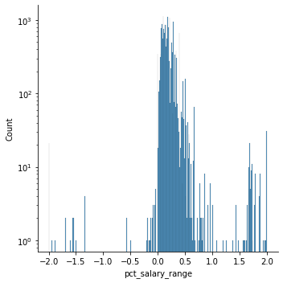

```python
sns.displot(df, x='pct_salary_range', log=True)
```

These are a mix of data and parsing errors mainly.

```python
df[df.pct_salary_range < 0].sort_values("pct_salary_range", ascending=False).T
```

|  | 63599 | 56453 | 64389 | 51887 | 24311 | 12435 | 15939 | 14756 | 66978 | 65907 | 56155 | 57303 | 64093 | 65883 | 57174 | 64504 | 57089 | 65941 | 30645 | 60969 | 66461 | 59159 | 68619 | 52477 | 30451 | ... | 63103 | 68120 | 38574 | … |
| --- | --- | --- | --- | --- | --- | --- | --- | --- | --- | --- | --- | --- | --- | --- | --- | --- | --- | --- | --- | --- | --- | --- | --- | --- | --- | --- | --- | --- | --- | --- |
| title | Estates/Litigation Lawyer *Exclusively Listed with Legal People* | Insurance/Transport Lawyer (3 years Plus exp.) | Estates/Litigation Lawyer *Exclusively Listed with Legal People* | Planning & Environment Lawyer | Legal Personal Assistant - Rare 1 on 1 Role! | Contracts Administrator | Contracts Administrator | Contracts Administrator | Senior 12D Designer. Big projects? | Civil Engineer - Principal. $177-162K. Admired team leader? | Senior Structural Engineer | Senior Communications Specialist | Principal Structural Engineer. $157-142K. | Senior Civil Engineer - Roads | Senior Structural Engineer $147-129K | Civil Drafter - Mid Level - Urban Development | Civil Associate $167-144K | Senior Tax Accountant | Quantity Surveyor Commercial Contractor, Tauranga | Senior Accountant $87-72K | Civil Engineer. Urban Infrastructure | Structural Principal $187-152k | Road Designers 12D | Full-Stack Mobile Developer | Project Coordinator / Project Administrator | ... | Intermediate Accountant - Top 50 Chartered Accounting firm - Sydney CBD | AUDITOR - TOP 50 FIRM - SYDNEY CBD - $70-90K | Management Accountant | … |
| description |  |  |  | About our client... Our client is a prestigious commercial law firm located in stunning offices, located in the heart of public transport, gyms an... | Are you a talented Legal Personal Assistant wanting “that something extra” in your role? If so, this role will certainly appeal. About the ... | About the Company\nEstablished over 40 years ago this highly respected builder who are highly regarded throughout Queensland are looking to add a ... | About the Company\nEstablished over 40 years ago this highly respected builder who are highly regarded throughout Queensland are looking to add a ... | About the Company\nEstablished over 40 years ago this highly respected builder who are highly regarded throughout Queensland are looking to add a ... |  |  |  |  |  |  |  |  |  |  | We are seeking a seeking a QS to become part of the cohesive and professional team within this well recognized regional commercial contractor. Th... |  |  |  |  | Are you ready to make the move into an inspiring team without the political road blocks that will allow you to drive innovation? Currently we have... | Are you a Project Coordinator / Project Administrator with incredible service & delivery skills, wanting to join one of the fastest growing & inno... | ... |  |  | Management Accountant\n\nPart Time - 30.5 hours per week\nSalary $78.3K to $85.2K (Band 6) + 9.5% Super\nLocation - Broadford\n\nMitchell Shire Co... | … |
| uri | https://www.seek.com.au/job/37438702 | https://www.seek.com.au/job/37059637 | https://www.seek.com.au/job/37438542 | https://www.seek.com.au/job/36028216 | https://www.seek.com.au/job/39973604 | https://www.cgcrecruitment.com/job/contracts-administrator-100/ | https://www.cgcrecruitment.com/job/contracts-administrator-100/ | https://www.cgcrecruitment.com/job/contracts-administrator-100/ | https://www.seek.com.au/job/37211440 | https://www.seek.com.au/job/37210798 | https://www.seek.com.au/job/37059579 | https://www.seek.co.nz/job/37345166 | https://www.seek.co.nz/job/37434420 | https://www.seek.com.au/job/37211332 | https://www.seek.co.nz/job/37348386 | https://www.seek.com.au/job/37436882 | https://www.seek.co.nz/job/37348385 | https://www.seek.com.au/job/37211069 | https://www.seek.co.nz/job/40268139 | https://www.seek.com.au/job/36498238 | https://www.seek.com.au/job/37211330 | https://www.seek.co.nz/job/37764568 | https://www.seek.com.au/job/37597834 | https://www.seek.com.au/job/36211544 | https://www.seek.com.au/job/39893421 | ... | https://www.seek.com.au/job/36787246 | https://www.seek.com.au/job/37599445 | https://www.seek.com.au/job/50986299?type=standout | … |
| view_date | 2018-10-11 00:51:57 | 2018-08-27 01:09:54 | 2018-10-11 00:52:33 | 2018-04-20 03:52:38 | 2019-09-19 10:15:08 | 2020-07-06 02:01:01+00:00 | 2020-09-30 11:44:39+00:00 | 2020-04-01 22:04:58+00:00 | 2018-09-13 01:02:12 | 2018-09-13 01:26:44 | 2018-08-27 01:08:03 | 2018-09-29 02:44:03 | 2018-10-11 01:58:43 | 2018-09-13 01:22:15 | 2018-09-29 02:48:49 | 2018-10-11 01:10:25 | 2018-09-29 02:43:25 | 2018-09-13 01:19:44 | 2019-10-29 12:48:48 | 2018-06-19 02:17:02 | 2018-09-13 01:23:09 | 2018-11-21 03:27:05 | 2018-10-31 02:33:55 | 2018-05-14 01:32:59 | 2019-09-09 10:02:29 | ... | 2018-07-24 09:28:52 | 2018-10-31 02:11:16 | 2020-12-04 04:10:07+00:00 | … |
| org | Legal People | Legal People | Legal People | Legal People | Legal People | CGC Recruitment | CGC Recruitment | CGC Recruitment | ENGINEERJOBS.com.au | ENGINEERJOBS.com.au | ENGINEERJOBS.com.au | Madison Recruitment Ltd | StructuralJobs.co.nz | ENGINEERJOBS.com.au | StructuralJobs.co.nz | ENGINEERJOBS.com.au | CivilJobs.co.nz | AccountantJobs.com.au | Harper Smith Recruitment | AccountantJobs.com.au | ENGINEERJOBS.com.au | StructuralJobs.co.nz | Bayside Personnel | Northbridge Recruitment | Aurec | ... | Lucky You Found Me | Lucky You Found Me | Mitchell Shire Council | … |
| salary_raw | Call Sharon Henderson: 9098-8776 | Call Sharon Henderson: 9098-8776 | Call Sharon Henderson: 9098-8776 | Call Sharon Henderson: 9098-8776 | Call Rosie at Legal People on 9098-8775 | $110K-$104K package depending on experience | $110K-$104K package depending on experience | $110K-$104K package depending on experience | $120,000 - $110,000 | $177,000-$162,000 | $149,000 to $136,000 | $55 - $50 per hour | $157,000 - $142,000 | $138,000 - $122,000 | $147,000 - $129,000 | $87,000 - $76,000 | $167,000 - $144,000 | $84,000 - $72,000 | $120,000 - $100,000 plus vehicle | $87,000 - $72,000 | $124,000 - $102,000 | $187,000 - $152,000 | $100 - $60 p.h. + Brisbane Based + perks | L/T CONTRACT, Excellent Rates, 9-5 hrs, Melb CBD | Good Rates + Great Manager + 9-5 hrs | ... | PLEASE CONTACT YULIUS ON 9283-0777 TO DISCUSS | PLEASE CONTACT YULIUS ON 9283-0777 TO DISCUSS | Salary $78.3K to $85.2K (Band 6) + 9.5% Super | … |
| salary_min | 9098 | 9098 | 9098 | 9098 | 9098 | 110000 | 110000 | 110000 | 120000 | 177000 | 149000 | 55 | 157000 | 138000 | 147000 | 87000 | 167000 | 84000 | 120000 | 87000 | 124000 | 187000 | 100 | 9 | 9 | ... | 9283 | 9283 | 3000 | … |
| salary_max | 8776 | 8776 | 8776 | 8776 | 8775 | 104000 | 104000 | 104000 | 110000 | 162000 | 136000 | 50 | 142000 | 122000 | 129000 | 76000 | 144000 | 72000 | 100000 | 72000 | 102000 | 152000 | 60 | 5 | 5 | ... | 777 | 777 | 85.2 | … |
| salary_hours | NaN | NaN | NaN | NaN | NaN | NaN | NaN | NaN | NaN | NaN | NaN | 1 | NaN | NaN | NaN | NaN | NaN | NaN | NaN | NaN | NaN | NaN | 1 | NaN | NaN | ... | NaN | NaN | NaN | … |
| location_raw | Melbourne, CBD & Inner Suburbs, AU | Melbourne, CBD & Inner Suburbs, AU | Melbourne, CBD & Inner Suburbs, AU | Melbourne, CBD & Inner Suburbs, AU | Melbourne, Victoria, Australia | Cairns, QLD Other, AU | Cairns, QLD Other, AU | Cairns, QLD Other, AU | Brisbane, Northern Suburbs, AU | Brisbane, CBD & Inner Suburbs, AU | Brisbane, CBD & Inner Suburbs, AU | Auckland, Auckland Central, NZ | Auckland, Auckland Central, NZ | Blue Mountains & Central West, AU | Auckland, Auckland Central, NZ | Gold Coast, AU | Auckland, Auckland Central, NZ | Melbourne, Eastern Suburbs, AU | Bay of Plenty, New Zealand, New zealand | Melbourne, CBD & Inner Suburbs, AU | Melbourne, CBD & Inner Suburbs, AU | Auckland, Auckland Central, NZ | Brisbane, AU | Melbourne, CBD & Inner Suburbs, AU | Sydney, New South Wales, Australia | ... | Sydney, CBD, Inner West & Eastern Suburbs, AU | Sydney, CBD, Inner West & Eastern Suburbs, AU | , Melbourne, Victoria, Australia | … |
| loc_id | 8.57823e+07 | 8.57823e+07 | 8.57823e+07 | 8.57823e+07 | 1.01933e+08 | 1.02049e+08 | 1.02049e+08 | 1.02049e+08 | 1.01934e+08 | 8.57823e+07 | 8.57823e+07 | 8.57824e+07 | 8.57824e+07 | 1.0205e+08 | 8.57824e+07 | 1.02049e+08 | 8.57824e+07 | 1.01933e+08 | 8.56872e+07 | 8.57823e+07 | 8.57823e+07 | 8.57824e+07 | 1.01934e+08 | 8.57823e+07 | 1.01932e+08 | ... | 8.57823e+07 | 8.57823e+07 | 1.01933e+08 | … |
| loc_continent | Oceania | Oceania | Oceania | Oceania | Oceania | Oceania | Oceania | Oceania | Oceania | Oceania | Oceania | Oceania | Oceania | Oceania | Oceania | Oceania | Oceania | Oceania | Oceania | Oceania | Oceania | Oceania | Oceania | Oceania | Oceania | ... | Oceania | Oceania | Oceania | … |
| loc_country | Australia | Australia | Australia | Australia | Australia | Australia | Australia | Australia | Australia | Australia | Australia | New Zealand | New Zealand | Australia | New Zealand | Australia | New Zealand | Australia | New Zealand | Australia | Australia | New Zealand | Australia | Australia | Australia | ... | Australia | Australia | Australia | … |
| loc_county | Melbourne | Melbourne | Melbourne | Melbourne | Melbourne | Cairns | Cairns | Cairns | Brisbane | Melbourne | Melbourne | Auckland | Auckland | Blue Mountains | Auckland | Gold Coast | Auckland | Melbourne | None | Melbourne | Melbourne | Auckland | Brisbane | Melbourne | Sydney | ... | Melbourne | Melbourne | Melbourne | … |
| loc_empire | Australia | Australia | Australia | Australia | Australia | Australia | Australia | Australia | Australia | Australia | Australia | None | None | Australia | None | Australia | None | Australia | None | Australia | Australia | None | Australia | Australia | Australia | ... | Australia | Australia | Australia | … |
| loc_localadmin | Melbourne | Melbourne | Melbourne | Melbourne | Melbourne | None | None | None | Brisbane City | Melbourne | Melbourne | None | None | None | None | None | None | Melbourne | None | Melbourne | Melbourne | None | Brisbane City | Melbourne | Sydney | ... | Melbourne | Melbourne | Melbourne | … |
| loc_locality | Melbourne | Melbourne | Melbourne | Melbourne | Melbourne | None | None | None | Brisbane City | Melbourne | Melbourne | None | None | None | None | None | None | Melbourne | None | Melbourne | Melbourne | None | Brisbane City | Melbourne | Sydney | ... | Melbourne | Melbourne | Melbourne | … |
| loc_macrocounty | Melbourne | Melbourne | Melbourne | Melbourne | Melbourne | None | None | None | Brisbane | Melbourne | Melbourne | None | None | None | None | Gold Coast | None | Melbourne | None | Melbourne | Melbourne | None | Brisbane | Melbourne | Sydney | ... | Melbourne | Melbourne | Melbourne | … |
| loc_region | Victoria | Victoria | Victoria | Victoria | Victoria | Queensland | Queensland | Queensland | Queensland | Victoria | Victoria | Auckland Region | Auckland Region | New South Wales | Auckland Region | Queensland | Auckland Region | Victoria | Bay of Plenty Region | Victoria | Victoria | Auckland Region | Queensland | Victoria | New South Wales | ... | Victoria | Victoria | Victoria | … |
| processor | kaggle_promptcloud_listings | kaggle_promptcloud_listings | kaggle_promptcloud_listings | kaggle_promptcloud_listings | kaggle_promptcloud_latest | cgcrecruitment | cgcrecruitment | cgcrecruitment | kaggle_promptcloud_listings | kaggle_promptcloud_listings | kaggle_promptcloud_listings | kaggle_promptcloud_listings | kaggle_promptcloud_listings | kaggle_promptcloud_listings | kaggle_promptcloud_listings | kaggle_promptcloud_listings | kaggle_promptcloud_listings | kaggle_promptcloud_listings | kaggle_promptcloud_latest | kaggle_promptcloud_listings | kaggle_promptcloud_listings | kaggle_promptcloud_listings | kaggle_promptcloud_listings | kaggle_promptcloud_listings | kaggle_promptcloud_latest | ... | kaggle_promptcloud_listings | kaggle_promptcloud_listings | seek | … |
| source | seekau | seekau | seekau | seekau | seekau_2019q3 | CC-MAIN-2020-29 | CC-MAIN-2020-40 | CC-MAIN-2020-16 | seekau | seekau | seekau | seekau | seekau | seekau | seekau | seekau | seekau | seekau | seekau_2019q3 | seekau | seekau | seekau | seekau | seekau | seekau_2019q3 | ... | seekau | seekau | CC-MAIN-2020-50 | … |
| loc_neighbourhood | Melbourne CBD | Melbourne CBD | Melbourne CBD | Melbourne CBD | None | NaN | NaN | NaN | None | Melbourne CBD | Melbourne CBD | Auckland City Centre | Auckland City Centre | None | Auckland City Centre | None | Auckland City Centre | None | None | Melbourne CBD | Melbourne CBD | Auckland City Centre | None | Melbourne CBD | None | ... | Melbourne CBD | Melbourne CBD | None | … |
| annual | False | False | False | False | False | False | False | False | False | False | False | False | False | False | False | False | False | False | False | False | False | False | False | False | False | ... | False | False | False | … |
| weekly | False | False | False | False | False | False | False | False | False | False | False | False | False | False | False | False | False | False | False | False | False | False | False | False | False | ... | False | False | False | … |
| daily | False | False | False | False | False | False | False | False | False | False | False | False | False | False | False | False | False | False | False | False | False | False | False | False | False | ... | False | False | False | … |
| hourly | False | False | False | False | False | False | False | False | False | False | False | True | False | False | False | False | False | False | False | False | False | False | True | False | False | ... | False | False | False | … |
| salary_low | 9098 | 9098 | 9098 | 9098 | 9098 | 110000 | 110000 | 110000 | 120000 | 177000 | 149000 | 55 | 157000 | 138000 | 147000 | 87000 | 167000 | 84000 | 120000 | 87000 | 124000 | 187000 | 100 | 9 | 9 | ... | 9283 | 9283 | 3000 | … |
| salary_hi | 8776 | 8776 | 8776 | 8776 | 8775 | 104000 | 104000 | 104000 | 110000 | 162000 | 136000 | 50 | 142000 | 122000 | 129000 | 76000 | 144000 | 72000 | 100000 | 72000 | 102000 | 152000 | 60 | 5 | 5 | ... | 777 | 777 | 85.2 | … |
| salary_valid | True | True | True | True | True | True | True | True | True | True | True | True | True | True | True | True | True | True | True | True | True | True | True | True | True | ... | True | True | True | … |
| pct_salary_range | -0.03603 | -0.03603 | -0.03603 | -0.03603 | -0.0361439 | -0.0560748 | -0.0560748 | -0.0560748 | -0.0869565 | -0.0884956 | -0.0912281 | -0.0952381 | -0.100334 | -0.123077 | -0.130435 | -0.134969 | -0.14791 | -0.153846 | -0.181818 | -0.188679 | -0.19469 | -0.20649 | -0.5 | -0.571429 | -0.571429 | ... | -1.69105 | -1.69105 | -1.88954 | … |

30 rows × 60 columns

```python
df.loc[df.pct_salary_range < 0, "salary_valid"] = False
```

A lot of crazy ranges, up to ~1.5 actually occur in the data, espeically for sales roles with variable income (it's safe to say the real income is at the bottom of the range). The rest are data/parsing errors.

Most of these ranges are pretty useless.

```python
df[df.pct_salary_range > .7].sort_values('pct_salary_range').T
```

|  | 68903 | 68838 | 23201 | 57159 | 18179 | 3563 | 667 | 11682 | 5911 | 24127 | 5592 | 3981 | 32572 | 35961 | 37972 | 59537 | 4148 | 5894 | 34767 | 35652 | 26830 | 8252 | 33312 | 9413 | 3915 | ... | 61633 | 60054 | 55842 | … |
| --- | --- | --- | --- | --- | --- | --- | --- | --- | --- | --- | --- | --- | --- | --- | --- | --- | --- | --- | --- | --- | --- | --- | --- | --- | --- | --- | --- | --- | --- | --- |
| title | Financial Advice & Sales | Financial Advice & Sales | Real Estate Sales Agent/Assistant | Auto Electrician - Heavy Earthmoving Equipment Experience | OHW Engineers (Engineer, Senior & Principal) | Chief Executive Officer - City of Melbourne | Project Manager - Contract | OHW Engineers (Engineer, Senior & Principal) | Project Manager - Contract | EXPERIENCED & CORDIAL FUNCTION WAIT STAFF | Sales Manager - Gold Coast | Sales Manager - Gold Coast | window Server consultant | window Server consultant | Customer Service \| Entry level | Mid Level Drupal Developer (Contract) | Android Developer- NAB | Android Developer- NAB | Business Development Manager - NSW, ACT & QLD | Business Development Manager - NSW, ACT & QLD | Professional PERMANENT and TEMPORARY job opportunities! | Administrator | Business Development Manager - NSW, ACT & QLD | Business Improvement Manager | Business Improvement Manager | ... | Acountant - Business Services Manager - $145 - $120K Add value to your Career | Construction Litigation Associate | Senior Accountant | … |
| description |  |  | About the business A well-established agency for over 30 years is looking for a motivated residential salesperson who is self motivated and is e... |  | CGC are working with a highly professional, world leading design and engineering consultancy. They have a highly enviable reputation and offer fle... | The City of Melbourne is a capital city council with ambitious plans for a fast-growing Melbourne.\nReporting to a highly engaged Lord Mayor and C... | About the Company\nLeading university looking for a project manager to start immediately – 6 month contract\nAbout the Role\n\n6 month contract wi... | CGC are working with a highly professional, world leading design and engineering consultancy. They have a highly enviable reputation and offer fle... | About the Company\nLeading university looking for a project manager to start immediately – 6 month contract\nAbout the Role\n\n6 month contract wi... | What's in it for you?Top hourly rates from $26.03 per hour paid weekly.Work at reputable establishments all over Canberra from Stadiums to Hotels ... | About the Company\nDavidson are recruiting to a Sales Professional – Home and land sale packages for our Client who are a successful, growing busi... | About the Company\nDavidson are recruiting to a Sales Professional – Home and land sale packages for our Client who are a successful, growing busi... | Your role is to migration legacy applications running on legacy servers Microsoft Server.\nYou will need the following skills\n\nAdvanced Windows ... | Your role is to migration legacy applications running on legacy servers Microsoft Server.\nYou will need the following skills\n\nAdvanced Windows ... | Entry Level \| Customer Service\nIf you have no corporate experience and wish to enter the NSW government space, these roles are not to be missed! ... |  | About the Company\nThis business is a true household name across Austalia. They are a well renowned, located in the CBD and they have an outstandi... | About the Company\nThis business is a true household name across Austalia. They are a well renowned, located in the CBD and they have an outstandi... | Our Client\nOur client has over 100K employees globally and provides a range of well-respected power management solutions, including UPS. They off... | Our Client\nOur client has over 100K employees globally and provides a range of well-respected power management solutions, including UPS. They off... | Personnel Resources / Temp Resources Ltd have been in the local market for over 20 years! With offices in Rotorua, Tauranga, and Whakatane we are ... | About the Company\nOur client is one of Australia's largest Financial Institutions, they provide a comprehensive and integrated range of Financial... | Our Client\nOur client has over 100K employees globally and provides a range of well-respected power management solutions, including UPS. They off... | About the Company\nOur client is one of Australians leading, independent coal producers. For more information regarding the client, please contact... | About the Company\nOur client is one of Australians leading, independent coal producers. For more information regarding the client, please contact... | ... |  |  |  | … |
| uri | https://www.seek.co.nz/job/36424224 | https://www.seek.co.nz/job/36424192 | https://www.seek.com.au/job/39865277 | https://www.seek.com.au/job/37345189 | https://www.cgcrecruitment.com/job/ohw-engineers-engineer-senior-and-principal/ | https://www.davidsonwp.com/job/100562133240635/chief-executive-officer-1/ | https://www.davidsonwp.com/job/100562133321419/project-manager-temp/ | https://www.cgcrecruitment.com/job/ohw-engineers-engineer-senior-and-principal/ | https://www.davidsonwp.com/job/100562133321419/project-manager-temp/ | https://www.seek.com.au/job/39968796 | https://www.davidsonwp.com/job/100562133295720/sales-manager-gold-coast-2/ | https://www.davidsonwp.com/job/100562133295720/sales-manager-gold-coast-2/ | https://jobs.launchrecruitment.com.au/job/100602033393926/window-server-consultant/ | https://jobs.launchrecruitment.com.au/job/100602033393926/window-server-consultant/ | https://www.seek.com.au/job/50821248?type=standard | https://www.seek.com.au/job/36553878 | https://www.davidsonwp.com/job/100562133321048/android-developer-nab/ | https://www.davidsonwp.com/job/100562133321048/android-developer-nab/ | https://jobs.launchrecruitment.com.au/job/100602033339088/business-development-manager-nsw-act-and-qld/ | https://jobs.launchrecruitment.com.au/job/100602033339088/business-development-manager-nsw-act-and-qld/ | https://www.seek.co.nz/job/40247000 | https://www.davidsonwp.com/job/administrator-1/ | https://jobs.launchrecruitment.com.au/job/100602033339088/business-development-manager-nsw-act-and-qld/ | https://www.davidsonwp.com/job/100562133286230/business-development-manager-8/ | https://www.davidsonwp.com/job/100562133286230/business-development-manager-8/ | ... | https://www.seek.com.au/job/36498235 | https://www.seek.com.au/job/36553569 | https://www.seek.com.au/job/37058079 | … |
| view_date | 2018-06-08 07:25:15 | 2018-06-08 07:23:55 | 2019-09-05 06:53:19 | 2018-09-29 02:49:04 | 2020-10-27 22:17:51+00:00 | 2020-04-02 23:59:07+00:00 | 2020-06-06 22:21:20+00:00 | 2020-06-05 03:27:31+00:00 | 2020-09-24 13:26:16+00:00 | 2019-09-18 09:50:23 | 2020-09-25 04:34:42+00:00 | 2020-04-06 05:39:33+00:00 | 2020-05-26 06:37:27+00:00 | 2020-09-28 23:55:30+00:00 | 2020-11-24 21:14:47+00:00 | 2018-06-25 16:28:10 | 2020-03-28 10:54:37+00:00 | 2020-09-27 04:24:57+00:00 | 2020-03-29 23:24:56+00:00 | 2020-09-24 04:57:34+00:00 | 2019-10-25 08:25:04 | 2020-08-11 23:46:22+00:00 | 2020-07-07 15:28:15+00:00 | 2020-10-22 01:25:53+00:00 | 2020-04-07 16:24:45+00:00 | ... | 2018-06-19 02:05:35 | 2018-06-25 16:46:44 | 2018-08-27 01:23:29 | … |
| org | Haven Advisers | Haven Advisers | Private Advertiser | GO2 Recruitment | CGC Recruitment | Davidson | Davidson | CGC Recruitment | Davidson | Frontline Hospitality Temps ACT & Southern NSW | Davidson | Davidson | Launch Recruitment | Launch Recruitment | Randstad - Business Support | Opus Recruitment Solutions | Davidson | Davidson | Launch Recruitment | Launch Recruitment | Personnel Resources/Temp Resources | Davidson | Launch Recruitment | Davidson | Davidson | ... | AccountantJobs.com.au | LAWJOBS.com.au - PERSONNEL CONCEPT | AccountantJobs.com.au | … |
| salary_raw | Year 1 OTE: $70,000 - $150,000+ | Year 1 OTE: $70,000 - $150,000+ | $55,000 - $120,000 wages and commission | $43 - $96.25 p.h. + Plus accommodation & Meals | $80,000 - $180,000 + Benefits | $200000 - $450000 per annum | $80000 - $180000 per annum | $80,000 - $180,000 + Benefits | $80000 - $180000 per annum | $26 - $59 p.h. | $65700 - $150000 per annum | $65700 - $150000 per annum | $300 - $700 per day | $300 - $700 per day | $27.5 - $65 p.a. + super on top | $250 - $600 per day | $350 - $850 per annum | $350 - $850 per annum | $80000 - $200000 per annum, Benefits: Base + car allowance + super + coms | $80000 - $200000 per annum, Benefits: Base + car allowance + super + coms | $40,000 - $100,000 | AU$100 - AU$250 per day + training,commission | $80000 - $200000 per annum, Benefits: Base + car allowance + super + coms | $800 - $2000 per day | $800 - $2000 per day | ... | $145 - $120K call/TXT Daniel Lyon 0409 125 722 | 138-115K | $105-88K. Call/SMS Mariam 0424522052 | … |
| salary_min | 70000 | 70000 | 55000 | 43 | 80000 | 200000 | 80000 | 80000 | 80000 | 26 | 65700 | 65700 | 300 | 300 | 27.5 | 250 | 350 | 350 | 80000 | 80000 | 40000 | 100 | 80000 | 800 | 800 | ... | 145 | 138 | 105 | … |
| salary_max | 150000 | 150000 | 120000 | 96.25 | 180000 | 450000 | 180000 | 180000 | 180000 | 59 | 150000 | 150000 | 700 | 700 | 65 | 600 | 850 | 850 | 200000 | 200000 | 100000 | 250 | 200000 | 2000 | 2000 | ... | 120000 | 115000 | 88000 | … |
| salary_hours | 2000 | 2000 | NaN | 1 | NaN | 2000 | 2000 | NaN | 2000 | 1 | 2000 | 2000 | 8 | 8 | 2000 | 8 | 2000 | 2000 | 2000 | 2000 | NaN | 8 | 2000 | 8 | 8 | ... | NaN | NaN | NaN | … |
| location_raw | Canterbury, Christchurch, NZ | Auckland, Papakura & Franklin, NZ | Sydney, New South Wales, Australia | Gladstone & Central QLD, AU | Sydney, AU | Melbourne, AU | Melbourne, AU | Sydney, AU | Melbourne, AU | ACT, Australian Capital Territory, Australia | Gold Coast Mc, AU | Gold Coast Mc, AU | Perth, AU | Perth, AU | parramatta, Sydney, New South Wales, Australia | Melbourne, CBD & Inner Suburbs, AU | Melbourne, AU | Melbourne, AU | Sydney, AU | Sydney, AU | Bay of Plenty, New Zealand, New zealand | Sydney, New South Wales, AU | Sydney, AU | Gunnedah, AU | Gunnedah, AU | ... | Melbourne, CBD & Inner Suburbs, AU | Perth, CBD, Inner & Western Suburbs, AU | ACT, AU | … |
| loc_id | 1.01915e+08 | 1.01915e+08 | 1.01932e+08 | 1.02049e+08 | 1.01932e+08 | 1.01933e+08 | 1.01933e+08 | 1.01932e+08 | 1.01933e+08 | 8.56815e+07 | 1.02048e+08 | 1.02048e+08 | 1.01938e+08 | 1.01938e+08 | 1.0205e+08 | 8.57823e+07 | 1.01933e+08 | 1.01933e+08 | 1.01932e+08 | 1.01932e+08 | 8.56872e+07 | 1.01932e+08 | 1.01932e+08 | 1.02049e+08 | 1.02049e+08 | ... | 8.57823e+07 | 8.57823e+07 | 8.56815e+07 | … |
| loc_continent | Oceania | Oceania | Oceania | Oceania | Oceania | Oceania | Oceania | Oceania | Oceania | Oceania | Oceania | Oceania | Oceania | Oceania | Oceania | Oceania | Oceania | Oceania | Oceania | Oceania | Oceania | Oceania | Oceania | Oceania | Oceania | ... | Oceania | Oceania | Oceania | … |
| loc_country | New Zealand | New Zealand | Australia | Australia | Australia | Australia | Australia | Australia | Australia | Australia | Australia | Australia | Australia | Australia | Australia | Australia | Australia | Australia | Australia | Australia | New Zealand | Australia | Australia | Australia | Australia | ... | Australia | Australia | Australia | … |
| loc_county | Christchurch City | Auckland | Sydney | Gladstone | Sydney | Melbourne | Melbourne | Sydney | Melbourne | None | Mitchell | Mitchell | Perth | Perth | Parramatta | Melbourne | Melbourne | Melbourne | Sydney | Sydney | None | Sydney | Sydney | Gunnedah | Gunnedah | ... | Melbourne | Perth | None | … |
| loc_empire | None | None | Australia | Australia | Australia | Australia | Australia | Australia | Australia | Australia | Australia | Australia | Australia | Australia | Australia | Australia | Australia | Australia | Australia | Australia | None | Australia | Australia | Australia | Australia | ... | Australia | Australia | Australia | … |
| loc_localadmin | None | None | Sydney | None | Sydney | Melbourne | Melbourne | Sydney | Melbourne | None | None | None | Perth | Perth | None | Melbourne | Melbourne | Melbourne | Sydney | Sydney | None | Sydney | Sydney | None | None | ... | Melbourne | Perth | None | … |
| loc_locality | Christchurch | Papakura | Sydney | None | Sydney | Melbourne | Melbourne | Sydney | Melbourne | None | None | None | Perth | Perth | None | Melbourne | Melbourne | Melbourne | Sydney | Sydney | None | Sydney | Sydney | None | None | ... | Melbourne | Perth | None | … |
| loc_macrocounty | None | None | Sydney | None | Sydney | Melbourne | Melbourne | Sydney | Melbourne | None | None | None | Perth | Perth | Sydney | Melbourne | Melbourne | Melbourne | Sydney | Sydney | None | Sydney | Sydney | None | None | ... | Melbourne | Perth | None | … |
| loc_region | Canterbury Region | Auckland Region | New South Wales | Queensland | New South Wales | Victoria | Victoria | New South Wales | Victoria | Australian Capital Territory | Victoria | Victoria | Western Australia | Western Australia | New South Wales | Victoria | Victoria | Victoria | New South Wales | New South Wales | Bay of Plenty Region | New South Wales | New South Wales | New South Wales | New South Wales | ... | Victoria | Western Australia | Australian Capital Territory | … |
| processor | kaggle_promptcloud_listings | kaggle_promptcloud_listings | kaggle_promptcloud_latest | kaggle_promptcloud_listings | cgcrecruitment | davidsonwp | davidsonwp | cgcrecruitment | davidsonwp | kaggle_promptcloud_latest | davidsonwp | davidsonwp | launchrecruitment | launchrecruitment | seek | kaggle_promptcloud_listings | davidsonwp | davidsonwp | launchrecruitment | launchrecruitment | kaggle_promptcloud_latest | davidsonwp | launchrecruitment | davidsonwp | davidsonwp | ... | kaggle_promptcloud_listings | kaggle_promptcloud_listings | kaggle_promptcloud_listings | … |
| source | seekau | seekau | seekau_2019q3 | seekau | CC-MAIN-2020-45 | CC-MAIN-2020-16 | CC-MAIN-2020-24 | CC-MAIN-2020-24 | CC-MAIN-2020-40 | seekau_2019q3 | CC-MAIN-2020-40 | CC-MAIN-2020-16 | CC-MAIN-2020-24 | CC-MAIN-2020-40 | CC-MAIN-2020-50 | seekau | CC-MAIN-2020-16 | CC-MAIN-2020-40 | CC-MAIN-2020-16 | CC-MAIN-2020-40 | seekau_2019q3 | CC-MAIN-2020-34 | CC-MAIN-2020-29 | CC-MAIN-2020-45 | CC-MAIN-2020-16 | ... | seekau | seekau | seekau | … |
| loc_neighbourhood | None | None | None | None | NaN | None | None | NaN | None | None | None | None | None | None | None | Melbourne CBD | None | None | None | None | None | None | None | None | None | ... | Melbourne CBD | Perth CBD | None | … |
| annual | True | True | False | False | False | True | True | False | True | False | True | True | False | False | True | False | True | True | True | True | False | False | True | False | False | ... | False | False | False | … |
| weekly | False | False | False | False | False | False | False | False | False | False | False | False | False | False | False | False | False | False | False | False | False | False | False | False | False | ... | False | False | False | … |
| daily | False | False | False | False | False | False | False | False | False | False | False | False | True | True | False | True | False | False | False | False | False | True | False | True | True | ... | False | False | False | … |
| hourly | False | False | False | True | False | False | False | False | False | True | False | False | False | False | False | False | False | False | False | False | False | False | False | False | False | ... | False | False | False | … |
| salary_low | 70000 | 70000 | 55000 | 43 | 80000 | 200000 | 80000 | 80000 | 80000 | 26 | 65700 | 65700 | 300 | 300 | 27.5 | 250 | 350 | 350 | 80000 | 80000 | 40000 | 100 | 80000 | 800 | 800 | ... | 145 | 138 | 105 | … |
| salary_hi | 150000 | 150000 | 120000 | 96.25 | 180000 | 450000 | 180000 | 180000 | 180000 | 59 | 150000 | 150000 | 700 | 700 | 65 | 600 | 850 | 850 | 200000 | 200000 | 100000 | 250 | 200000 | 2000 | 2000 | ... | 120000 | 115000 | 88000 | … |
| salary_valid | True | True | True | True | True | True | True | True | True | True | True | True | True | True | True | True | True | True | True | True | True | True | True | True | True | ... | True | True | True | … |
| pct_salary_range | 0.727273 | 0.727273 | 0.742857 | 0.764811 | 0.769231 | 0.769231 | 0.769231 | 0.769231 | 0.769231 | 0.776471 | 0.781641 | 0.781641 | 0.8 | 0.8 | 0.810811 | 0.823529 | 0.833333 | 0.833333 | 0.857143 | 0.857143 | 0.857143 | 0.857143 | 0.857143 | 0.857143 | 0.857143 | ... | 1.99517 | 1.99521 | 1.99523 | … |

30 rows × 172 columns

```python
df.loc[df.pct_salary_range > 1.5, "salary_valid"] = False
```

## Overall Minimum Salary

```
CPU times: user 350 ms, sys: 103 ms, total: 452 ms
Wall time: 326 ms
```

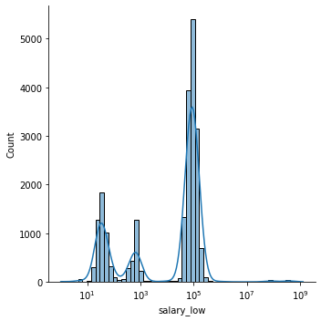

```python
%time sns.displot(df, x="salary_low", log_scale=True, kde=True)
```

```
CPU times: user 379 ms, sys: 65.8 ms, total: 445 ms
Wall time: 319 ms
```

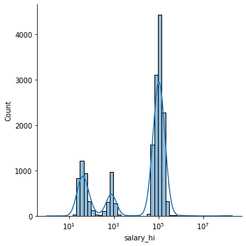

```python
%time sns.displot(df, x="salary_hi", log_scale=True, kde=True)
```

Above about 500k it gets suss

```python
df[df.salary_low > 500_000].sort_values("salary_low").T
```

|  | 34383 | 32963 | 36900 | 6001 | 5873 | 4212 | 4138 | 39504 | 5599 | 3990 | 13992 | 12789 | 3827 | 380 | 9323 | 32722 | 34105 | 127 | 3315 | 4491 | 9064 | 330 | 3678 | 1657 | 17909 | ... | 60805 | 60404 | 58749 | … |
| --- | --- | --- | --- | --- | --- | --- | --- | --- | --- | --- | --- | --- | --- | --- | --- | --- | --- | --- | --- | --- | --- | --- | --- | --- | --- | --- | --- | --- | --- | --- |
| title | Receptionist POC | Receptionist POC | Draftsperson | UX/UI Designer | Front End Developer | UX/UI Designer | Front End Developer | Marketing and Events Coordinator | Document Controller | Document Controller | Office Manager / Accountant | Office Manager / Accountant | Senior Android Engineer | Senior Android Engineer | Senior Android Engineer | Full Stack Developer | Full Stack Developer | Signallers | Senior Quantity Surveyor | Senior Quantity Surveyor | Lead Commissioning Engineer | Lead Commissioning Engineer | Lead Commissioning Engineer | Lead Commissioning Engineer | General Foreman | ... | Principal Structure Engineer - Up to $211K. Accelerate your Career? | 12d Designer $108-85K. Great time to choose | Registered Surveyors $161-128K Multiple Choices | … |
| description | Our client, a multi-service IT provider is currently seeking an experienced Receptionist for a permanent full time position. In this diverse role ... | Our client, a multi-service IT provider is currently seeking an experienced Receptionist for a permanent full time position. In this diverse role ... | Your new company\nHays are currently working with a reputable company based in the Canberra region. This particular company work on large scale co... | My client is a large corporation with operations across the world. They have their headquarters based in Brisbane, giving you access to global pro... | My client is a large corporation with operations across the world. They are currently expanding their team due to increased project work. They are... | My client is a large corporation with operations across the world. They have their headquarters based in Brisbane, giving you access to global pro... | My client is a large corporation with operations across the world. They are currently expanding their team due to increased project work. They are... | Northern Territory PHN leads the development and coordination of an equitable, comprehensive primary health care system and an engaged health work... | About the Company\nDavidson are currently working with one of the world’s largest names in wind energy. This company manufactures, installs and se... | About the Company\nDavidson are currently working with one of the world’s largest names in wind energy. This company manufactures, installs and se... | The Company\nProject Management Consultancy who specialise in a range of project sectors valued up to $120 Million, have an exciting and extremely... | The Company\nProject Management Consultancy who specialise in a range of project sectors valued up to $120 Million, have an exciting and extremely... | One of Melbourne's most desirable start-ups are looking to hire a Senior Android Developer to join their team of high performing developers.\nBein... | One of Melbourne's most desirable start-ups are looking to hire a Senior Android Developer to join their team of high performing developers.\nBein... | One of Melbourne's most desirable start-ups are looking to hire a Senior Android Developer to join their team of high performing developers.\nBein... | Great opportunity working for a unique company, who roll out solutions across Australia before scaling globally.\n\nJoin a rapid growing organisat... | Great opportunity working for a unique company, who roll out solutions across Australia before scaling globally.\n\nJoin a rapid growing organisat... | Davidson is excited to be partnering with Metro Trains Melbourne to appoint four Signallers for their Network Signalling division in Melbourne.\nM... | Company:\nOur Client is a multiple award winning, Australian owned, premier QS practice that is currently seeking the capabilities of an passionat... | Company:\nOur Client is a multiple award winning, Australian owned, premier QS practice that is currently seeking the capabilities of an passionat... | About the Company\nFounded in Urumqi, China, Goldwind is one of the world's leading wind power companies. The largest player in the wind industry ... | About the Company\nFounded in Urumqi, China, Goldwind is one of the world's leading wind power companies. The largest player in the wind industry ... | About the Company\nFounded in Urumqi, China, Goldwind is one of the world's leading wind power companies. The largest player in the wind industry ... | About the Company\nFounded in Urumqi, China, Goldwind is one of the world's leading wind power companies. The largest player in the wind industry ... | The Company\nOur client is known local Sydney builder who partners with prestigious developers delivering multi million-dollar projects across the... | ... |  |  |  | … |
| uri | https://jobs.launchrecruitment.com.au/job/100602033258906/receptionist-poc-1/ | https://jobs.launchrecruitment.com.au/job/100602033258906/receptionist-poc-1/ | https://www.seek.com.au/job/41362846?type=standard | https://www.davidsonwp.com/job/100562133327232/ux-slash-ui-designer/ | https://www.davidsonwp.com/job/100562133319740/front-end-developer-8/ | https://www.davidsonwp.com/job/100562133327232/ux-slash-ui-designer/ | https://www.davidsonwp.com/job/100562133319740/front-end-developer-8/ | https://www.seek.com.au/job/41204953?type=standout | https://www.davidsonwp.com/job/100562133297159/document-controller/ | https://www.davidsonwp.com/job/100562133297159/document-controller/ | https://www.cgcrecruitment.com/job/office-manager-slash-accountant-2/ | https://www.cgcrecruitment.com/job/office-manager-slash-accountant-2/ | https://www.davidsonwp.com/job/100562133270808/senior-android-engineer/ | https://www.davidsonwp.com/job/100562133272648/senior-android-engineer-1/ | https://www.davidsonwp.com/job/100562133270808/senior-android-engineer/ | https://jobs.launchrecruitment.com.au/job/100602033189052/full-stack-developer/ | https://jobs.launchrecruitment.com.au/job/100602033189052/full-stack-developer/ | https://www.davidsonwp.com/job/100562133248138/signallers-1/ | https://www.davidsonwp.com/job/100562133361033/senior-quantity-surveyor-5/ | https://www.davidsonwp.com/job/100562133361033/senior-quantity-surveyor-5/ | https://www.davidsonwp.com/job/100562133254581/lead-commissioning-engineer/ | https://www.davidsonwp.com/job/100562133267469/lead-commissioning-engineer-1/ | https://www.davidsonwp.com/job/100562133254581/lead-commissioning-engineer/ | https://www.davidsonwp.com/job/100562133254581/lead-commissioning-engineer/ | https://www.cgcrecruitment.com/job/general-foreman-3/ | ... | https://www.seek.com.au/job/36553908 | https://www.seek.com.au/job/36554083 | https://www.seek.com.au/job/37763876 | … |
| view_date | 2020-04-08 20:49:20+00:00 | 2020-07-02 01:53:50+00:00 | 2020-05-31 08:52:15+00:00 | 2020-09-18 00:45:40+00:00 | 2020-09-28 22:26:46+00:00 | 2020-04-03 12:22:01+00:00 | 2020-03-29 11:13:38+00:00 | 2020-03-28 18:53:37+00:00 | 2020-09-28 20:28:34+00:00 | 2020-03-31 20:21:49+00:00 | 2020-11-27 23:43:35+00:00 | 2020-07-13 10:52:05+00:00 | 2020-04-07 16:04:01+00:00 | 2020-06-05 08:54:21+00:00 | 2020-10-22 01:04:53+00:00 | 2020-07-03 03:29:56+00:00 | 2020-04-05 23:10:42+00:00 | 2020-05-30 21:03:15+00:00 | 2020-11-23 16:23:14+00:00 | 2020-03-28 09:43:42+00:00 | 2020-10-28 17:50:29+00:00 | 2020-05-30 20:34:13+00:00 | 2020-04-02 23:46:43+00:00 | 2020-07-14 15:46:51+00:00 | 2020-10-21 05:57:39+00:00 | ... | 2018-06-25 16:27:19 | 2018-06-25 16:29:02 | 2018-11-21 02:16:18 | … |
| org | Launch Recruitment | Launch Recruitment | Hays Architecture | Davidson | Davidson | Davidson | Davidson | Northern Territory PHN | Davidson | Davidson | CGC Recruitment | CGC Recruitment | Davidson | Davidson | Davidson | Launch Recruitment | Launch Recruitment | Davidson | Davidson | Davidson | Davidson | Davidson | Davidson | Davidson | CGC Recruitment | ... | ENGINEERJOBS.com.au | ENGINEERJOBS.com.au | SurveyorJobs.com.au | … |
| salary_raw | $0 - $650000 per annum | $0 - $650000 per annum | $70,0000 - $100,000 + Superannuation | $700000 per annum | $700000 per annum | $700000 per annum | $700000 per annum | $72,6640 - $80,715 pro-rata + super | $750000 per annum | $750000 per annum | $85,0000 - $110,000 depending on experience. | $85,0000 - $110,000 depending on experience. | $1000000 - $1400000 per annum | $1000000 - $1400000 per annum | $1000000 - $1400000 per annum | $0 - $1000000 per annum | $0 - $1000000 per annum | $1100000 per annum | $1200000 per annum | $1200000 per annum | $1250000 per annum | $1250000 per annum | $1250000 per annum | $1250000 per annum | $130,0000 - $160,000 | ... | Or call/txt Roger 0418494245 in confidence | Confidentially call / text Roger on 0418494245 | Or Call/SMS Pieter on 0419 490 660 in Confidence | … |
| salary_min | 0 | 0 | 700000 | 700000 | 700000 | 700000 | 700000 | 726640 | 750000 | 750000 | 850000 | 850000 | 1e+06 | 1e+06 | 1e+06 | 0 | 0 | 1.1e+06 | 1.2e+06 | 1.2e+06 | 1.25e+06 | 1.25e+06 | 1.25e+06 | 1.25e+06 | 1.3e+06 | ... | 4.18494e+08 | 4.18494e+08 | 4.19491e+08 | … |
| salary_max | 650000 | 650000 | 100000 | NaN | NaN | NaN | NaN | 80715 | NaN | NaN | 110000 | 110000 | 1.4e+06 | 1.4e+06 | 1.4e+06 | 1e+06 | 1e+06 | NaN | NaN | NaN | NaN | NaN | NaN | NaN | 160000 | ... | NaN | NaN | NaN | … |
| salary_hours | 2000 | 2000 | NaN | 2000 | 2000 | 2000 | 2000 | NaN | 2000 | 2000 | NaN | NaN | 2000 | 2000 | 2000 | 2000 | 2000 | 2000 | 2000 | 2000 | 2000 | 2000 | 2000 | 2000 | NaN | ... | NaN | NaN | NaN | … |
| location_raw | Sydney, AU | Sydney, AU | canberra, ACT, Australian Capital Territory, Australia | Brisbane, AU | Brisbane, AU | Brisbane, AU | Brisbane, AU | darwin, Darwin, Northern Territories, Australia | Canberra, AU | Canberra, AU | Sydney, AU | Sydney, AU | Melbourne, AU | Melbourne, AU | Melbourne, AU | Sydney, AU | Sydney, AU | Melbourne, AU | Melbourne, AU | Melbourne, AU | Sydney, AU | Melbourne, AU | Sydney, AU | Sydney, AU | Sydney, AU | ... | Sydney, CBD, Inner West & Eastern Suburbs, AU | Sydney, CBD, Inner West & Eastern Suburbs, AU | Sydney, CBD, Inner West & Eastern Suburbs, AU | … |
| loc_id | 1.01932e+08 | 1.01932e+08 | 1.37695e+09 | 1.01934e+08 | 1.01934e+08 | 1.01934e+08 | 1.01934e+08 | NaN | 8.56815e+07 | 8.56815e+07 | 1.01932e+08 | 1.01932e+08 | 1.01933e+08 | 1.01933e+08 | 1.01933e+08 | 1.01932e+08 | 1.01932e+08 | 1.01933e+08 | 1.01933e+08 | 1.01933e+08 | 1.01932e+08 | 1.01933e+08 | 1.01932e+08 | 1.01932e+08 | 1.01932e+08 | ... | 8.57823e+07 | 8.57823e+07 | 8.57823e+07 | … |
| loc_continent | Oceania | Oceania | Oceania | Oceania | Oceania | Oceania | Oceania | None | Oceania | Oceania | Oceania | Oceania | Oceania | Oceania | Oceania | Oceania | Oceania | Oceania | Oceania | Oceania | Oceania | Oceania | Oceania | Oceania | Oceania | ... | Oceania | Oceania | Oceania | … |
| loc_country | Australia | Australia | Australia | Australia | Australia | Australia | Australia | None | Australia | Australia | Australia | Australia | Australia | Australia | Australia | Australia | Australia | Australia | Australia | Australia | Australia | Australia | Australia | Australia | Australia | ... | Australia | Australia | Australia | … |
| loc_county | Sydney | Sydney | None | Brisbane | Brisbane | Brisbane | Brisbane | None | None | None | Sydney | Sydney | Melbourne | Melbourne | Melbourne | Sydney | Sydney | Melbourne | Melbourne | Melbourne | Sydney | Melbourne | Sydney | Sydney | Sydney | ... | Melbourne | Melbourne | Melbourne | … |
| loc_empire | Australia | Australia | Australia | Australia | Australia | Australia | Australia | None | Australia | Australia | Australia | Australia | Australia | Australia | Australia | Australia | Australia | Australia | Australia | Australia | Australia | Australia | Australia | Australia | Australia | ... | Australia | Australia | Australia | … |
| loc_localadmin | Sydney | Sydney | None | Brisbane City | Brisbane City | Brisbane City | Brisbane City | None | None | None | Sydney | Sydney | Melbourne | Melbourne | Melbourne | Sydney | Sydney | Melbourne | Melbourne | Melbourne | Sydney | Melbourne | Sydney | Sydney | Sydney | ... | Melbourne | Melbourne | Melbourne | … |
| loc_locality | Sydney | Sydney | None | Brisbane City | Brisbane City | Brisbane City | Brisbane City | None | None | None | Sydney | Sydney | Melbourne | Melbourne | Melbourne | Sydney | Sydney | Melbourne | Melbourne | Melbourne | Sydney | Melbourne | Sydney | Sydney | Sydney | ... | Melbourne | Melbourne | Melbourne | … |
| loc_macrocounty | Sydney | Sydney | Canberra | Brisbane | Brisbane | Brisbane | Brisbane | None | None | None | Sydney | Sydney | Melbourne | Melbourne | Melbourne | Sydney | Sydney | Melbourne | Melbourne | Melbourne | Sydney | Melbourne | Sydney | Sydney | Sydney | ... | Melbourne | Melbourne | Melbourne | … |
| loc_region | New South Wales | New South Wales | Australian Capital Territory | Queensland | Queensland | Queensland | Queensland | None | Australian Capital Territory | Australian Capital Territory | New South Wales | New South Wales | Victoria | Victoria | Victoria | New South Wales | New South Wales | Victoria | Victoria | Victoria | New South Wales | Victoria | New South Wales | New South Wales | New South Wales | ... | Victoria | Victoria | Victoria | … |
| processor | launchrecruitment | launchrecruitment | seek | davidsonwp | davidsonwp | davidsonwp | davidsonwp | seek | davidsonwp | davidsonwp | cgcrecruitment | cgcrecruitment | davidsonwp | davidsonwp | davidsonwp | launchrecruitment | launchrecruitment | davidsonwp | davidsonwp | davidsonwp | davidsonwp | davidsonwp | davidsonwp | davidsonwp | cgcrecruitment | ... | kaggle_promptcloud_listings | kaggle_promptcloud_listings | kaggle_promptcloud_listings | … |
| source | CC-MAIN-2020-16 | CC-MAIN-2020-29 | CC-MAIN-2020-24 | CC-MAIN-2020-40 | CC-MAIN-2020-40 | CC-MAIN-2020-16 | CC-MAIN-2020-16 | CC-MAIN-2020-16 | CC-MAIN-2020-40 | CC-MAIN-2020-16 | CC-MAIN-2020-50 | CC-MAIN-2020-29 | CC-MAIN-2020-16 | CC-MAIN-2020-24 | CC-MAIN-2020-45 | CC-MAIN-2020-29 | CC-MAIN-2020-16 | CC-MAIN-2020-24 | CC-MAIN-2020-50 | CC-MAIN-2020-16 | CC-MAIN-2020-45 | CC-MAIN-2020-24 | CC-MAIN-2020-16 | CC-MAIN-2020-29 | CC-MAIN-2020-45 | ... | seekau | seekau | seekau | … |
| loc_neighbourhood | None | None | None | None | None | None | None | None | None | None | NaN | NaN | None | None | None | None | None | None | None | None | None | None | None | None | NaN | ... | Melbourne CBD | Melbourne CBD | Melbourne CBD | … |
| annual | True | True | False | True | True | True | True | False | True | True | False | False | True | True | True | True | True | True | True | True | True | True | True | True | False | ... | False | False | False | … |
| weekly | False | False | False | False | False | False | False | False | False | False | False | False | False | False | False | False | False | False | False | False | False | False | False | False | False | ... | False | False | False | … |
| daily | False | False | False | False | False | False | False | False | False | False | False | False | False | False | False | False | False | False | False | False | False | False | False | False | False | ... | False | False | False | … |
| hourly | False | False | False | False | False | False | False | False | False | False | False | False | False | False | False | False | False | False | False | False | False | False | False | False | False | ... | False | False | False | … |
| salary_low | 650000 | 650000 | 700000 | 700000 | 700000 | 700000 | 700000 | 726640 | 750000 | 750000 | 850000 | 850000 | 1e+06 | 1e+06 | 1e+06 | 1e+06 | 1e+06 | 1.1e+06 | 1.2e+06 | 1.2e+06 | 1.25e+06 | 1.25e+06 | 1.25e+06 | 1.25e+06 | 1.3e+06 | ... | 4.18494e+08 | 4.18494e+08 | 4.19491e+08 | … |
| salary_hi | NaN | NaN | 100000 | NaN | NaN | NaN | NaN | 80715 | NaN | NaN | 110000 | 110000 | 1.4e+06 | 1.4e+06 | 1.4e+06 | NaN | NaN | NaN | NaN | NaN | NaN | NaN | NaN | NaN | 160000 | ... | NaN | NaN | NaN | … |
| salary_valid | True | True | False | True | True | True | True | False | True | True | False | False | True | True | True | True | True | True | True | True | True | True | True | True | False | ... | True | True | True | … |
| pct_salary_range | NaN | NaN | -1.5 | NaN | NaN | NaN | NaN | -1.6001 | NaN | NaN | -1.54167 | -1.54167 | 0.333333 | 0.333333 | 0.333333 | NaN | NaN | NaN | NaN | NaN | NaN | NaN | NaN | NaN | -1.56164 | ... | NaN | NaN | NaN | … |

30 rows × 169 columns

Below 15 it's mostly garbage

```python
df[df.salary_low < 15].sort_values("salary_low", ascending=False).T
```

|  | 22495 | 70099 | 33446 | 56590 | 4756 | 35215 | 34908 | 70436 | 34342 | 27168 | 35941 | 40049 | 33740 | 32932 | 60928 | 60179 | 18705 | 12027 | 10360 | 34056 | 35491 | 58947 | 40428 | 54330 | 36064 | ... | 21332 | 32918 | 34321 | … |
| --- | --- | --- | --- | --- | --- | --- | --- | --- | --- | --- | --- | --- | --- | --- | --- | --- | --- | --- | --- | --- | --- | --- | --- | --- | --- | --- | --- | --- | --- | --- |
| title | Fundraising and Support Officer | Apprentice Gardener | Lifecycle Marketing Manager | Project Engineer - Substations | C# .NET Software Developer | Direct Product Manager - Insurance | Lifecycle Marketing Manager | Junior Java Software Developer | Executive Manager of Product and Services | Senior Test Analyst - 12m Fixed Term | Direct Product Manager - Insurance | Business Operations Manager | Direct Product Manager - Insurance | Executive Manager of Product and Services | Diplomatic Safety Assurance and Audit Leader | Sponsorship & Events Producer | Senior Tunnel Engineer | Senior Tunnel Engineer | C# .NET Software Developer | Test post from idibu | Test post from idibu | Customer Support Team Leader | Refrigeration Apprenticeship | Looking for a 1st or 2nd year Landscape Apprentice | Fulfillment Centre Operations Manager - Night Shifts | ... | Looking for female cleaner and cook | SAP Customer Management | SAP Customer Management | … |
| description | About Canteen We help young people cope with cancer in their family. Through CanTeen, they learn to explore and deal with their feelings about can... |  | Our Client\nBased in the CBD, our client is a global eCommerce provider and a household name for consumers to sell and purchase online. They provi... |  | My client is looking for experienced .NET Developers to join their agile environment working on multiple complex systems.\nWork on high traffic, p... | Direct Product Manager required to work on a large Insurance integration. This role requires a Product Manager with Insurance experience to drive,... | Our Client\nBased in the CBD, our client is a global eCommerce provider and a household name for consumers to sell and purchase online. They provi... |  | A national Telco company has a senior position available for an Executive Manager to lead the end to end product management of their key products ... | H2R Technology has an amazing opportunity for a Senior Test Analyst to join a dynamic team responsible for providing testing solutions for everyth... | Direct Product Manager required to work on a large Insurance integration. This role requires a Product Manager with Insurance experience to drive,... |  About Us\nWebcentral Group is Australia’s largest full-service digital services partner for small and medium businesses. We’ve supported th... | Direct Product Manager required to work on a large Insurance integration. This role requires a Product Manager with Insurance experience to drive,... | A national Telco company has a senior position available for an Executive Manager to lead the end to end product management of their key products ... |  |  | The Company\nWith offices across the globe, this top tier engineering design consultancy are at the forefront of design. They have an outstanding... | The Company\nWith offices across the globe, this top tier engineering design consultancy are at the forefront of design. They have an outstanding... | My client is looking for experienced .NET Developers to join their agile environment working on multiple complex systems.\nWork on high traffic, p... | This is a test post from idibu\n\nThis is a test post from idibu\nThis is a test post from idibu\nThis is a test post from idibu\nThis is a test p... | This is a test post from idibu\n\nThis is a test post from idibu\nThis is a test post from idibu\nThis is a test post from idibu\nThis is a test p... |  | Ford and Doonan Air Conditioning Bunbury are seeking a full time apprentice refrigeration mechanic to add to our team.\nPrinciple Duties/ Responsi... | -Our company specializes in all aspects of Residential landscaping projects. -You will be required to have your drivers license and vehicle. -Yo... | My client is seeking an experienced, Operations Manager to join our Customer Fulfillment team in Dandenong\nKey points of interest:\n\nNight shift... | ... | We are busy couple. Looking for someone female from Bangladeshi India Nepal or Pakistani to clean our unit 3 days every week and helping cooking I... | SAP Customer Management – SAP CRM – SAP IS-U – 12-month initial contract\nThis is a key role is a large SAP implementation and Business Transforma... | SAP Customer Management – SAP CRM – SAP IS-U – 12-month initial contract\nThis is a key role is a large SAP implementation and Business Transforma... | … |
| uri | https://www.seek.com.au/job/39856340 | https://www.seek.com.au/job/37563482 | https://jobs.launchrecruitment.com.au/job/100602033360111/lifecycle-marketing-manager/ | https://www.seek.com.au/job/36740858 | https://www.davidsonwp.com/job/c-number-net-software-developer-1/ | https://jobs.launchrecruitment.com.au/job/100602033391109/direct-product-manager-insurance/ | https://jobs.launchrecruitment.com.au/job/100602033360111/lifecycle-marketing-manager/ | https://www.seek.com.au/job/37563519 | https://jobs.launchrecruitment.com.au/job/100602033250174/executive-manager-of-product-and-services/ | https://www.seek.co.nz/job/40236720 | https://jobs.launchrecruitment.com.au/job/100602033391109/direct-product-manager-insurance/ | https://www.seek.com.au/job/50224723?type=standout | https://jobs.launchrecruitment.com.au/job/100602033391109/direct-product-manager-insurance/ | https://jobs.launchrecruitment.com.au/job/100602033250174/executive-manager-of-product-and-services/ | https://www.seek.com.au/job/36500995 | https://www.seek.com.au/job/36554264 | https://www.cgcrecruitment.com/job/senior-tunnel-engineer/ | https://www.cgcrecruitment.com/job/senior-tunnel-engineer/ | https://www.davidsonwp.com/job/c-number-net-software-developer-1/ | https://jobs.launchrecruitment.com.au/job/test-post-from-idibu/ | https://jobs.launchrecruitment.com.au/job/test-post-from-idibu/ | https://www.seek.com.au/job/37751145 | https://www.seek.com.au/job/50696090?type=standard | https://www.seek.com.au/job/36031584 | https://jobs.launchrecruitment.com.au/job/fulfillment-centre-operations-manager-night-shifts/ | ... | https://www.gumtree.com.au/s-ad/lakemba/other/looking-for-female-cleaner-and-cook/1248628669 | https://jobs.launchrecruitment.com.au/job/100602033243699/sap-customer-management/ | https://jobs.launchrecruitment.com.au/job/100602033243699/sap-customer-management/ | … |
| view_date | 2019-09-04 08:19:23 | 2018-10-26 04:32:05 | 2020-07-16 05:44:09+00:00 | 2018-07-19 06:10:01 | 2020-04-02 23:30:16+00:00 | 2020-04-05 23:32:21+00:00 | 2020-04-09 15:42:31+00:00 | 2018-10-26 04:46:59 | 2020-04-07 00:39:07+00:00 | 2019-10-26 11:33:44 | 2020-09-29 17:32:37+00:00 | 2020-08-05 22:08:45+00:00 | 2020-07-08 12:44:57+00:00 | 2020-07-05 17:07:59+00:00 | 2018-06-19 01:36:16 | 2018-06-25 16:07:24 | 2020-10-27 22:21:39+00:00 | 2020-06-05 16:21:23+00:00 | 2020-10-24 00:31:19+00:00 | 2020-07-05 17:04:34+00:00 | 2020-04-07 00:35:49+00:00 | 2018-11-21 02:14:29 | 2020-10-24 09:29:22+00:00 | 2018-04-20 02:55:48 | 2020-09-29 01:24:17+00:00 | ... | 2020-05-24 23:19:10+00:00 | 2020-07-05 06:05:36+00:00 | 2020-04-04 06:30:27+00:00 | … |
| org | CanTeen | Treetops garden maintenance | Launch Recruitment | Metro Trains Melbourne | Davidson | Launch Recruitment | Launch Recruitment | The Citadel Group | Launch Recruitment | H2R Consulting | Launch Recruitment | Webcentral Group | Launch Recruitment | Launch Recruitment | Safety Australia Group | Screenwest Australia Limited | CGC Recruitment | CGC Recruitment | Davidson | Launch Recruitment | Launch Recruitment | Johns Lyng Group | Ford and Doonan Air Conditioning Bunbury | BDW Landscapes | Launch Recruitment | ... | None | Launch Recruitment | Launch Recruitment | … |
| salary_raw | Salary + Super \| Full time contract til 13 Dec 19 | $12.75 P/H | 12 month contract | 12 month, fixed-term contract | 12 Mth Fixed Term - Salary Based | 12 month contract | 12 month contract | Excellent rates!\n12 month contract | 12-Month Contract | 12 Month Fixed Term Contract | 12 month contract | Competitive Package + 12-month cover | 12 month contract | 12-Month Contract | Attractive Rate - 12 month contract and may extend | 12 month fixed term contract | $12-140k | $12-140k | 12 Mth Fixed Term - Salary Based | $11 - $111 per annum | $11 - $111 per annum | 11 Month Contract with Career Growth Opportunities | $10 - $14.99 per hour | $10 - $14.99 per hour | Hourly rate, 4 day weeks, Shifts 9.5 hours per day | ... | 3 Or 4 Hours | 3 year Transformation Project | 3 year Transformation Project | … |
| salary_min | 13 | 12.75 | 12 | 12 | 12 | 12 | 12 | 12 | 12 | 12 | 12 | 12 | 12 | 12 | 12 | 12 | 12 | 12 | 12 | 11 | 11 | 11 | 10 | 10 | 9.5 | ... | 3 | 3 | 3 | … |
| salary_max | NaN | NaN | NaN | NaN | NaN | NaN | NaN | NaN | NaN | NaN | NaN | NaN | NaN | NaN | NaN | NaN | 140000 | 140000 | NaN | 111 | 111 | NaN | 14.99 | 14.99 | NaN | ... | NaN | NaN | NaN | … |
| salary_hours | NaN | 1 | NaN | NaN | NaN | NaN | NaN | NaN | NaN | NaN | NaN | NaN | NaN | NaN | NaN | NaN | NaN | NaN | NaN | 2000 | 2000 | NaN | 1 | 1 | 1 | ... | NaN | 2000 | 2000 | … |
| location_raw | Sydney, New South Wales, Australia | Sydney, North West & Hills District, AU | Sydney, AU | Melbourne, Bayside & South Eastern Suburbs, AU | Melbourne CBD, Victoria, AU | Sydney, AU | Sydney, AU | ACT, AU | North Sydney, AU | Wellington, New Zealand, New zealand | Sydney, AU | melbourne, Melbourne, Victoria, Australia | Sydney, AU | North Sydney, AU | Sydney, CBD, Inner West & Eastern Suburbs, AU | Perth, CBD, Inner & Western Suburbs, AU | Melbourne, AU | Melbourne, AU | Melbourne CBD, Victoria, AU | Sydney, Nova Scotia, CA | Sydney, Nova Scotia, CA | Sydney, Parramatta & Western Suburbs, AU | bunbury, Bunbury & South West, Western Australia, Australia | Melbourne, CBD & Inner Suburbs, AU | Melbourne, AU | ... | Lakemba, Lakemba New South Wales, Australia | Sydney, AU | Sydney, AU | … |
| loc_id | 1.01932e+08 | 1.01932e+08 | 1.01932e+08 | 1.01933e+08 | 8.57823e+07 | 1.01932e+08 | 1.01932e+08 | 8.56815e+07 | 1.02049e+08 | 8.56872e+07 | 1.01932e+08 | 1.01933e+08 | 1.01932e+08 | 1.02049e+08 | 8.57823e+07 | 8.57823e+07 | 1.01933e+08 | 1.01933e+08 | 8.57823e+07 | NaN | NaN | 1.01932e+08 | 1.01937e+08 | 8.57823e+07 | 1.01933e+08 | ... | 1.01931e+08 | 1.01932e+08 | 1.01932e+08 | … |
| loc_continent | Oceania | Oceania | Oceania | Oceania | Oceania | Oceania | Oceania | Oceania | Oceania | Oceania | Oceania | Oceania | Oceania | Oceania | Oceania | Oceania | Oceania | Oceania | Oceania | None | None | Oceania | Oceania | Oceania | Oceania | ... | Oceania | Oceania | Oceania | … |
| loc_country | Australia | Australia | Australia | Australia | Australia | Australia | Australia | Australia | Australia | New Zealand | Australia | Australia | Australia | Australia | Australia | Australia | Australia | Australia | Australia | None | None | Australia | Australia | Australia | Australia | ... | Australia | Australia | Australia | … |
| loc_county | Sydney | Sydney | Sydney | Melbourne | Melbourne | Sydney | Sydney | None | North Sydney | None | Sydney | Melbourne | Sydney | North Sydney | Melbourne | Perth | Melbourne | Melbourne | Melbourne | None | None | Sydney | Bunbury | Melbourne | Melbourne | ... | Canterbury | Sydney | Sydney | … |
| loc_empire | Australia | Australia | Australia | Australia | Australia | Australia | Australia | Australia | Australia | None | Australia | Australia | Australia | Australia | Australia | Australia | Australia | Australia | Australia | None | None | Australia | Australia | Australia | Australia | ... | Australia | Australia | Australia | … |
| loc_localadmin | Sydney | Sydney | Sydney | Melbourne | Melbourne | Sydney | Sydney | None | None | None | Sydney | Melbourne | Sydney | None | Melbourne | Perth | Melbourne | Melbourne | Melbourne | None | None | Sydney | Bunbury | Melbourne | Melbourne | ... | Lakemba | Sydney | Sydney | … |
| loc_locality | Sydney | Sydney | Sydney | Melbourne | Melbourne | Sydney | Sydney | None | None | None | Sydney | Melbourne | Sydney | None | Melbourne | Perth | Melbourne | Melbourne | Melbourne | None | None | Sydney | Bunbury | Melbourne | Melbourne | ... | Lakemba | Sydney | Sydney | … |
| loc_macrocounty | Sydney | Sydney | Sydney | Melbourne | Melbourne | Sydney | Sydney | None | Sydney | None | Sydney | Melbourne | Sydney | Sydney | Melbourne | Perth | Melbourne | Melbourne | Melbourne | None | None | Sydney | Bunbury | Melbourne | Melbourne | ... | Sydney | Sydney | Sydney | … |
| loc_region | New South Wales | New South Wales | New South Wales | Victoria | Victoria | New South Wales | New South Wales | Australian Capital Territory | New South Wales | Wellington Region | New South Wales | Victoria | New South Wales | New South Wales | Victoria | Western Australia | Victoria | Victoria | Victoria | None | None | New South Wales | Western Australia | Victoria | Victoria | ... | New South Wales | New South Wales | New South Wales | … |
| processor | kaggle_promptcloud_latest | kaggle_promptcloud_listings | launchrecruitment | kaggle_promptcloud_listings | davidsonwp | launchrecruitment | launchrecruitment | kaggle_promptcloud_listings | launchrecruitment | kaggle_promptcloud_latest | launchrecruitment | seek | launchrecruitment | launchrecruitment | kaggle_promptcloud_listings | kaggle_promptcloud_listings | cgcrecruitment | cgcrecruitment | davidsonwp | launchrecruitment | launchrecruitment | kaggle_promptcloud_listings | seek | kaggle_promptcloud_listings | launchrecruitment | ... | gumtree | launchrecruitment | launchrecruitment | … |
| source | seekau_2019q3 | seekau | CC-MAIN-2020-29 | seekau | CC-MAIN-2020-16 | CC-MAIN-2020-16 | CC-MAIN-2020-16 | seekau | CC-MAIN-2020-16 | seekau_2019q3 | CC-MAIN-2020-40 | CC-MAIN-2020-34 | CC-MAIN-2020-29 | CC-MAIN-2020-29 | seekau | seekau | CC-MAIN-2020-45 | CC-MAIN-2020-24 | CC-MAIN-2020-45 | CC-MAIN-2020-29 | CC-MAIN-2020-16 | seekau | CC-MAIN-2020-45 | seekau | CC-MAIN-2020-40 | ... | CC-MAIN-2020-24 | CC-MAIN-2020-29 | CC-MAIN-2020-16 | … |
| loc_neighbourhood | None | None | None | None | Melbourne CBD | None | None | None | None | None | None | None | None | None | Melbourne CBD | Perth CBD | NaN | NaN | Melbourne CBD | None | None | None | None | Melbourne CBD | None | ... | None | None | None | … |
| annual | False | False | False | False | False | False | False | False | False | False | False | False | False | False | False | False | False | False | False | True | True | False | False | False | False | ... | False | True | True | … |
| weekly | False | False | False | False | False | False | False | False | False | False | False | False | False | False | False | False | False | False | False | False | False | False | False | False | False | ... | False | False | False | … |
| daily | False | False | False | False | False | False | False | False | False | False | False | False | False | False | False | False | False | False | False | False | False | False | False | False | False | ... | False | False | False | … |
| hourly | False | True | False | False | False | False | False | False | False | False | False | False | False | False | False | False | False | False | False | False | False | False | True | True | True | ... | False | False | False | … |
| salary_low | 13 | 12.75 | 12 | 12 | 12 | 12 | 12 | 12 | 12 | 12 | 12 | 12 | 12 | 12 | 12 | 12 | 12 | 12 | 12 | 11 | 11 | 11 | 10 | 10 | 9.5 | ... | 3 | 3 | 3 | … |
| salary_hi | NaN | NaN | NaN | NaN | NaN | NaN | NaN | NaN | NaN | NaN | NaN | NaN | NaN | NaN | NaN | NaN | 140000 | 140000 | NaN | 111 | 111 | NaN | 14.99 | 14.99 | NaN | ... | NaN | NaN | NaN | … |
| salary_valid | True | True | True | True | True | True | True | True | True | True | True | True | True | True | True | True | False | False | True | False | False | True | True | True | True | ... | True | True | True | … |
| pct_salary_range | NaN | NaN | NaN | NaN | NaN | NaN | NaN | NaN | NaN | NaN | NaN | NaN | NaN | NaN | NaN | NaN | 1.99966 | 1.99966 | NaN | 1.63934 | 1.63934 | NaN | 0.39936 | 0.39936 | NaN | ... | NaN | NaN | NaN | … |

30 rows × 127 columns

```python
SALARY_MIN_AUD = 15
SALARY_MAX_AUD = 500_000
```

```python
df.loc[df.salary_low < SALARY_MIN_AUD, "salary_valid"] = False
df.loc[df.salary_low > SALARY_MAX_AUD, "salary_valid"] = False
```

### Yearly

```
CPU times: user 629 ms, sys: 69.1 ms, total: 698 ms
Wall time: 593 ms
```

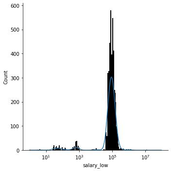

```python
%time sns.displot(df[df.annual], x="salary_low", log_scale=True, kde=True)
```

*Most* of these are data mistakes

```python
SALARY_ANNUAL_MIN_AUD = 20000
```

```python
df[(df.salary_low < SALARY_ANNUAL_MIN_AUD) & df.annual].sort_values("salary_low", ascending=False).T
```

|  | 10461 | 8542 | 10890 | 62274 | 3696 | 1673 | 9121 | 7153 | 6617 | 26908 | 6616 | 6561 | 4555 | 2269 | 10082 | 6553 | 979 | 61982 | 9210 | 19168 | 20004 | 4493 | 947 | 10047 | 10017 | ... | 70814 | 66290 | 24791 | … |
| --- | --- | --- | --- | --- | --- | --- | --- | --- | --- | --- | --- | --- | --- | --- | --- | --- | --- | --- | --- | --- | --- | --- | --- | --- | --- | --- | --- | --- | --- | --- |
| title | Director of Client Services / Financial Controller | Safety Systems Engineer | Safety Systems Engineer | Digital Success Consultant - Education & Online Learning | Senior Project Manager - Developer, Construction | Senior Project Manager - Developer, Construction | Senior Project Manager - Developer, Construction | Installation Supervisor (5months) | Technical Project Manager | 4 Assurance Mgrs- 6 Month Max Term contracts - $125k package | Manager, Executive Services (Chief of Staff) | Executive Manager | Manager, Executive Services (Chief of Staff) | Manager, Executive Services (Chief of Staff) | Manager, Executive Services (Chief of Staff) | Executive Manager | Manager, Executive Services (Chief of Staff) | Systems / DevOps Engineer - MS Azure skills required | PMO Analyst | Clinical Educator | Solicitor for NSW and Tasmania | BI Specialist | BI Specialist | BI Specialist | BI Specialist | ... | Customer Care Representative | Customer Servce Officer | EOI - General Laborers Required | … |
| description | About the Company\nMy client is a bespoke outsourced finance function for small to medium enterprises which includes reporting, virtual CFO functi... | About the Company\nDavidson Technology have partnered with a multi-national defence, security and aerospace company who are building one of the wo... | About the Company\nDavidson Technology have partnered with a multi-national defence, security and aerospace company who are building one of the wo... |  | About the Company\n\nIndustrial developer which develops and manages real estate on behalf of key clients\nPublicly listed, highly regarded global... | About the Company\n\nIndustrial developer which develops and manages real estate on behalf of key clients\nPublicly listed, highly regarded global... | About the Company\n\nIndustrial developer which develops and manages real estate on behalf of key clients\nPublicly listed, highly regarded global... | The Company\nDavidson is delighted to be partnering with Goldwind, one of the world's leading wind power companies in their search for an Installa... | About the Company\nOur client is a multinational construction and infrastructure company they help people, clients, and communities do great thing... | This leading bank is seeking 4 Assurance professionals with excellent stakeholder management skills to join their Line 2 Assurance team on 6 month... | A unique and rewarding opportunity has become available to join a growing, evolving and well-respected Not for Profit organisation. You will step ... | A unique and rewarding opportunity has become available to join a growing, evolving and well-respected Not for Profit organisation. You will step ... | A unique and rewarding opportunity has become available to join a growing, evolving and well-respected Not for Profit organisation. You will step ... | A unique and rewarding opportunity has become available to join a growing, evolving and well-respected Not for Profit organisation. You will step ... | A unique and rewarding opportunity has become available to join a growing, evolving and well-respected Not for Profit organisation. You will step ... | A unique and rewarding opportunity has become available to join a growing, evolving and well-respected Not for Profit organisation. You will step ... | A unique and rewarding opportunity has become available to join a growing, evolving and well-respected Not for Profit organisation. You will step ... |  | About the Company\nOne of Ausrtalia's largest professional membership organisations.\nAbout the Role\nThis role has two aspects to it...\n\nTo hel... | About the role\n\nNFP Salary Packaging options available\nLeading mental health organisation\nParkville location with onsite parking + close to pu... | About the role\nSUMMARY\n\nMust have or soon will have at least 3 years post-admission experience within Australia. Experience in New South Wale a... | Our client have their headquarters based in Brisbane, giving you access to global professional development and career opportunities!\nFantastic op... | Our client have their headquarters based in Brisbane, giving you access to global professional development and career opportunities!\nFantastic op... | Our client have their headquarters based in Brisbane, giving you access to global professional development and career opportunities!\nFantastic op... | Our client have their headquarters based in Brisbane, giving you access to global professional development and career opportunities!\nFantastic op... | ... |  |  | Our clients are based in Brisbane Southern Suburbs /Logan Area. We are looking for labourers to work on on-call, on-going and adhoc roles. Candida... | … |
| uri | https://www.davidsonwp.com/job/director-of-client-services-slash-financial-controller/ | https://www.davidsonwp.com/job/safety-systems-engineer/ | https://www.davidsonwp.com/job/safety-systems-engineer/ | https://www.seek.com.au/job/36500923 | https://www.davidsonwp.com/job/100562133257277/senior-project-manager-developer-construction/ | https://www.davidsonwp.com/job/100562133257277/senior-project-manager-developer-construction/ | https://www.davidsonwp.com/job/100562133257277/senior-project-manager-developer-construction/ | https://www.davidsonwp.com/job/installation-supervisor-5months/ | https://www.davidsonwp.com/job/100562133367068/technical-project-manager-1/ | https://www.seek.com.au/job/39894794 | https://www.davidsonwp.com/job/100562133367048/manager-executive-services-chief-of-staff-1/ | https://www.davidsonwp.com/job/100562133364046/executive-manager-1/ | https://www.davidsonwp.com/job/100562133367025/manager-executive-services-chief-of-staff/ | https://www.davidsonwp.com/job/100562133367025/manager-executive-services-chief-of-staff/ | https://www.davidsonwp.com/job/100562133367025/manager-executive-services-chief-of-staff/ | https://www.davidsonwp.com/job/100562133363681/executive-manager/ | https://www.davidsonwp.com/job/100562133367048/manager-executive-services-chief-of-staff-1/ | https://www.seek.com.au/job/36500248 | https://www.davidsonwp.com/job/100562133263296/pmo-analyst/ | https://probonoaustralia.com.au/jobs/2019/09/clinical-educator/ | https://probonoaustralia.com.au/jobs/2020/10/solicitor-for-nsw-and-tasmania/ | https://www.davidsonwp.com/job/100562133360565/bi-specialist-2/ | https://www.davidsonwp.com/job/100562133361996/bi-specialist-3/ | https://www.davidsonwp.com/job/100562133361996/bi-specialist-3/ | https://www.davidsonwp.com/job/100562133360565/bi-specialist-2/ | ... | https://www.seek.com.au/job/37563347 | https://www.seek.com.au/job/37211622 | https://www.seek.com.au/job/40042253 | … |
| view_date | 2020-10-30 12:10:24+00:00 | 2020-08-08 07:23:54+00:00 | 2020-10-25 05:17:32+00:00 | 2018-06-19 01:13:09 | 2020-04-05 09:29:40+00:00 | 2020-07-12 08:56:32+00:00 | 2020-10-22 06:37:25+00:00 | 2020-09-27 09:23:33+00:00 | 2020-09-27 18:44:42+00:00 | 2019-09-09 09:56:47 | 2020-09-29 02:36:37+00:00 | 2020-09-23 13:26:54+00:00 | 2020-04-05 09:56:10+00:00 | 2020-07-10 18:54:50+00:00 | 2020-10-29 03:08:18+00:00 | 2020-09-27 04:32:33+00:00 | 2020-05-30 10:16:55+00:00 | 2018-06-19 01:43:39 | 2020-10-22 23:28:02+00:00 | 2020-05-29 10:07:49+00:00 | 2020-12-04 03:48:55+00:00 | 2020-03-30 03:19:37+00:00 | 2020-05-29 02:34:13+00:00 | 2020-10-25 10:40:59+00:00 | 2020-10-20 10:07:22+00:00 | ... | 2018-10-26 04:37:05 | 2018-09-13 01:09:35 | 2019-09-27 07:27:25 | … |
| org | Davidson | Davidson | Davidson | BMS Sales Performance | Davidson | Davidson | Davidson | Davidson | Davidson | Bluefin Resources Pty Limited | Davidson | Davidson | Davidson | Davidson | Davidson | Davidson | Davidson | Spark Recruitment | Davidson | Orygen, The National Centre of Excellence in Youth Mental Health | Youth Law Australia | Davidson | Davidson | Davidson | Davidson | ... | people2people | Page Personnel | Adecco | … |
| salary_raw | AU$18000 - AU$150000 per annum + Plus Super | AU$18000 - AU$200000 per annum + training,commission | AU$18000 - AU$200000 per annum + training,commission | Up to $100000.00 p.a. + Car + $15 - $20k Commissio | $14000 - $165000 per annum | $14000 - $165000 per annum | $14000 - $165000 per annum | AU$13000 - AU$140000 per annum | $12000 - $16000 per annum | $11500.00 - $140000.00 p.a. + super | $10000 - $120000 per annum | $10000 - $120000 per annum | $10000 - $120000 per annum | $10000 - $120000 per annum | $10000 - $120000 per annum | $10000 - $120000 per annum | $10000 - $120000 per annum | $10000.00 - $110k p.a. | $10000 - $120000 per annum | $95,00 - $110,000 per annum (pro rata) (commensurate with skills and experience). | $90,00 - $105,000 p.a. (pro rata), negotiable + 9.5% Superannuation + Leave Loading + FBT Salary Packaging available. | $7500 - $98550 per annum | $7500 - $98550 per annum | $7500 - $98550 per annum | $7500 - $98550 per annum | ... | $25 - $30 per annum, Bens: $28.00 + Super | $25 - $26 p.a. | $24 - $30 p.a. | … |
| salary_min | 18000 | 18000 | 18000 | 15000 | 14000 | 14000 | 14000 | 13000 | 12000 | 11500 | 10000 | 10000 | 10000 | 10000 | 10000 | 10000 | 10000 | 10000 | 10000 | 9500 | 9000 | 7500 | 7500 | 7500 | 7500 | ... | 25 | 25 | 24 | … |
| salary_max | 150000 | 200000 | 200000 | 20000 | 165000 | 165000 | 165000 | 140000 | 16000 | 140000 | 120000 | 120000 | 120000 | 120000 | 120000 | 120000 | 120000 | 110000 | 120000 | 110000 | 105000 | 98550 | 98550 | 98550 | 98550 | ... | 30 | 26 | 30 | … |
| salary_hours | 2000 | 2000 | 2000 | 2000 | 2000 | 2000 | 2000 | 2000 | 2000 | 2000 | 2000 | 2000 | 2000 | 2000 | 2000 | 2000 | 2000 | 2000 | 2000 | 2000 | 2000 | 2000 | 2000 | 2000 | 2000 | ... | 2000 | 2000 | 2000 | … |
| location_raw | Brisbane, Queensland, AU | Melbourne CBD, Victoria, AU | Melbourne CBD, Victoria, AU | Sydney, CBD, Inner West & Eastern Suburbs, AU | Melbourne, AU | Melbourne, AU | Melbourne, AU | Goulburn, New South Wales, AU | Melbourne, AU | Sydney, New South Wales, Australia | Brisbane Adelaide Street, AU | Brisbane Adelaide Street, AU | Brisbane Adelaide Street, AU | Brisbane Adelaide Street, AU | Brisbane Adelaide Street, AU | Brisbane Adelaide Street, AU | Brisbane Adelaide Street, AU | Sydney, North Shore & Northern Beaches, AU | East Melbourne, AU | Melbourne(Parkville) | Hobart, Sydney, TAS Regional | Brisbane, AU | Brisbane, AU | Brisbane, AU | Brisbane, AU | ... | Sydney, Parramatta & Western Suburbs, AU | Perth, Northern Suburbs & Joondalup, AU | Brisbane, Queensland, Australia | … |
| loc_id | 1.01934e+08 | 8.57823e+07 | 8.57823e+07 | 8.57823e+07 | 1.01933e+08 | 1.01933e+08 | 1.01933e+08 | 1.0193e+08 | 1.01933e+08 | 1.01932e+08 | 1.01936e+08 | 1.01936e+08 | 1.01936e+08 | 1.01936e+08 | 1.01936e+08 | 1.01936e+08 | 1.01936e+08 | NaN | 1.01933e+08 | 1.01933e+08 | NaN | 1.01934e+08 | 1.01934e+08 | 1.01934e+08 | 1.01934e+08 | ... | 1.01932e+08 | 1.01938e+08 | 1.01934e+08 | … |
| loc_continent | Oceania | Oceania | Oceania | Oceania | Oceania | Oceania | Oceania | Oceania | Oceania | Oceania | Oceania | Oceania | Oceania | Oceania | Oceania | Oceania | Oceania | None | Oceania | Oceania | None | Oceania | Oceania | Oceania | Oceania | ... | Oceania | Oceania | Oceania | … |
| loc_country | Australia | Australia | Australia | Australia | Australia | Australia | Australia | Australia | Australia | Australia | Australia | Australia | Australia | Australia | Australia | Australia | Australia | None | Australia | Australia | None | Australia | Australia | Australia | Australia | ... | Australia | Australia | Australia | … |
| loc_county | Brisbane | Melbourne | Melbourne | Melbourne | Melbourne | Melbourne | Melbourne | Goulburn Mulwaree | Melbourne | Sydney | Adelaide | Adelaide | Adelaide | Adelaide | Adelaide | Adelaide | Adelaide | None | Melbourne | Melbourne | None | Brisbane | Brisbane | Brisbane | Brisbane | ... | Sydney | Perth | Brisbane | … |
| loc_empire | Australia | Australia | Australia | Australia | Australia | Australia | Australia | Australia | Australia | Australia | Australia | Australia | Australia | Australia | Australia | Australia | Australia | None | Australia | Australia | None | Australia | Australia | Australia | Australia | ... | Australia | Australia | Australia | … |
| loc_localadmin | Brisbane City | Melbourne | Melbourne | Melbourne | Melbourne | Melbourne | Melbourne | Goulburn | Melbourne | Sydney | Adelaide | Adelaide | Adelaide | Adelaide | Adelaide | Adelaide | Adelaide | None | East Melbourne | Parkville | None | Brisbane City | Brisbane City | Brisbane City | Brisbane City | ... | Sydney | Perth | Brisbane City | … |
| loc_locality | Brisbane City | Melbourne | Melbourne | Melbourne | Melbourne | Melbourne | Melbourne | Goulburn | Melbourne | Sydney | Adelaide | Adelaide | Adelaide | Adelaide | Adelaide | Adelaide | Adelaide | None | East Melbourne | Parkville | None | Brisbane City | Brisbane City | Brisbane City | Brisbane City | ... | Sydney | Perth | Brisbane City | … |
| loc_macrocounty | Brisbane | Melbourne | Melbourne | Melbourne | Melbourne | Melbourne | Melbourne | None | Melbourne | Sydney | Adelaide | Adelaide | Adelaide | Adelaide | Adelaide | Adelaide | Adelaide | None | Melbourne | Melbourne | None | Brisbane | Brisbane | Brisbane | Brisbane | ... | Sydney | Perth | Brisbane | … |
| loc_region | Queensland | Victoria | Victoria | Victoria | Victoria | Victoria | Victoria | New South Wales | Victoria | New South Wales | South Australia | South Australia | South Australia | South Australia | South Australia | South Australia | South Australia | None | Victoria | Victoria | None | Queensland | Queensland | Queensland | Queensland | ... | New South Wales | Western Australia | Queensland | … |
| processor | davidsonwp | davidsonwp | davidsonwp | kaggle_promptcloud_listings | davidsonwp | davidsonwp | davidsonwp | davidsonwp | davidsonwp | kaggle_promptcloud_latest | davidsonwp | davidsonwp | davidsonwp | davidsonwp | davidsonwp | davidsonwp | davidsonwp | kaggle_promptcloud_listings | davidsonwp | probono | probono | davidsonwp | davidsonwp | davidsonwp | davidsonwp | ... | kaggle_promptcloud_listings | kaggle_promptcloud_listings | kaggle_promptcloud_latest | … |
| source | CC-MAIN-2020-45 | CC-MAIN-2020-34 | CC-MAIN-2020-45 | seekau | CC-MAIN-2020-16 | CC-MAIN-2020-29 | CC-MAIN-2020-45 | CC-MAIN-2020-40 | CC-MAIN-2020-40 | seekau_2019q3 | CC-MAIN-2020-40 | CC-MAIN-2020-40 | CC-MAIN-2020-16 | CC-MAIN-2020-29 | CC-MAIN-2020-45 | CC-MAIN-2020-40 | CC-MAIN-2020-24 | seekau | CC-MAIN-2020-45 | CC-MAIN-2020-24 | CC-MAIN-2020-50 | CC-MAIN-2020-16 | CC-MAIN-2020-24 | CC-MAIN-2020-45 | CC-MAIN-2020-45 | ... | seekau | seekau | seekau_2019q3 | … |
| loc_neighbourhood | None | Melbourne CBD | Melbourne CBD | Melbourne CBD | None | None | None | None | None | None | None | None | None | None | None | None | None | None | None | None | None | None | None | None | None | ... | None | None | None | … |
| annual | True | True | True | True | True | True | True | True | True | True | True | True | True | True | True | True | True | True | True | True | True | True | True | True | True | ... | True | True | True | … |
| weekly | False | False | False | False | False | False | False | False | False | False | False | False | False | False | False | False | False | False | False | False | False | False | False | False | False | ... | False | False | False | … |
| daily | False | False | False | False | False | False | False | False | False | False | False | False | False | False | False | False | False | False | False | False | False | False | False | False | False | ... | False | False | False | … |
| hourly | False | False | False | False | False | False | False | False | False | False | False | False | False | False | False | False | False | False | False | False | False | False | False | False | False | ... | False | False | False | … |
| salary_low | 18000 | 18000 | 18000 | 15000 | 14000 | 14000 | 14000 | 13000 | 12000 | 11500 | 10000 | 10000 | 10000 | 10000 | 10000 | 10000 | 10000 | 10000 | 10000 | 9500 | 9000 | 7500 | 7500 | 7500 | 7500 | ... | 25 | 25 | 24 | … |
| salary_hi | 150000 | 200000 | 200000 | 20000 | 165000 | 165000 | 165000 | 140000 | 16000 | 140000 | 120000 | 120000 | 120000 | 120000 | 120000 | 120000 | 120000 | 110000 | 120000 | 110000 | 105000 | 98550 | 98550 | 98550 | 98550 | ... | 30 | 26 | 30 | … |
| salary_valid | False | False | False | True | False | False | False | False | True | False | False | False | False | False | False | False | False | False | False | False | False | False | False | False | False | ... | True | True | True | … |
| pct_salary_range | 1.57143 | 1.66972 | 1.66972 | 0.285714 | 1.68715 | 1.68715 | 1.68715 | 1.66013 | 0.285714 | 1.69637 | 1.69231 | 1.69231 | 1.69231 | 1.69231 | 1.69231 | 1.69231 | 1.69231 | 1.66667 | 1.69231 | 1.68201 | 1.68421 | 1.71711 | 1.71711 | 1.71711 | 1.71711 | ... | 0.181818 | 0.0392157 | 0.222222 | … |

30 rows × 431 columns

```python
df.loc[(df.salary_low < SALARY_ANNUAL_MIN_AUD) & df.annual, "salary_valid"] = False
```

```
CPU times: user 438 ms, sys: 61.2 ms, total: 500 ms
Wall time: 397 ms
```

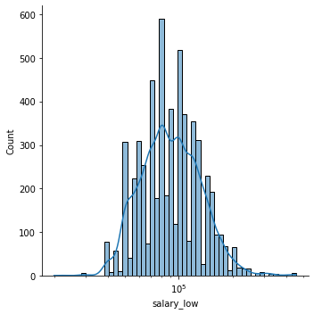

```python
%time sns.displot(df[(df.salary_hours==2000) & (df.salary_valid)], x="salary_low", log_scale=True, kde=True)
```

## Weekly

```
CPU times: user 523 ms, sys: 89.7 ms, total: 613 ms
Wall time: 522 ms
```

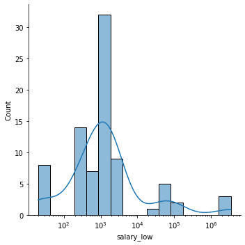

```python
%time sns.displot(df[df.weekly], x="salary_low", kde=True, log_scale=True)
```

These are mainly bad parsing; could tighen up parsing here

```python
SALARY_WEEKLY_MAX_AUD = 5000
```

```python
df[df.weekly & (df.salary_low > SALARY_WEEKLY_MAX_AUD)].sort_values("salary_low").T
```

|  | 21565 | 40654 | 62250 | 25836 | 68789 | 19335 | 20444 | 19957 | 59419 | 59863 | 60712 |
| --- | --- | --- | --- | --- | --- | --- | --- | --- | --- | --- | --- |
| title | Become a taxi driver | Social Media Marketing Assistant (Part Time 3 days per week) | Store Manager - Melbourne | Talent Resourcer | Run-Off Manager for Dairy Support | Office Manager – Community Colleges Australia | Registered Psychologist | HR Advisor | Election Managers | Election Managers | Election Manager |
| description | Need full driving victorian australian licence at least 1 year old . National police check and australian victorian driving license is must.\nIf a... | About us\nWe are a dynamic and integrated creative marketing and brand agency, offering thoughtful creative design, strategic marketing and manage... |  | In this fast paced role, you'll work in a team of 3 Recruiters handling all office and call centre recruitment for our Sydney branch, along with p... |  | About the role\nCommunity Colleges Australia (CCA: www.cca.edu.au), the peak national body that represents community-owned, not-for-profit educati... | About the role\n\nAre you passionate about improving the health and wellbeing of Aboriginal people?\nJoin an influential and supportive Not-For-Pr... | About the role\nCHOICE is one of Australia’s leading independent online media organisations; one that plays a unique role in the Australian consum... |  |  |  |
| uri | https://www.gumtree.com.au/s-ad/the-basin/other-jobs/become-a-taxi-driver/1258503131 | https://www.seek.com.au/job/50730953?type=standard | https://www.seek.com.au/job/36497803 | https://www.seek.com.au/job/40179061 | https://www.seek.co.nz/job/36421441 | https://probonoaustralia.com.au/jobs/2019/10/office-manager-community-colleges-australia/ | https://probonoaustralia.com.au/jobs/2020/08/registered-psychologist/ | https://probonoaustralia.com.au/jobs/2020/07/hr-advisor/ | https://www.seek.com.au/job/36554346 | https://www.seek.com.au/job/36554233 | https://www.seek.com.au/job/36554178 |
| view_date | 2020-11-27 09:14:12+00:00 | 2020-10-28 20:38:22+00:00 | 2018-06-19 02:23:09 | 2019-10-17 09:07:41 | 2018-06-08 07:23:50 | 2020-05-29 10:49:54+00:00 | 2020-09-26 11:40:24+00:00 | 2020-11-26 22:39:23+00:00 | 2018-06-25 16:11:41 | 2018-06-25 16:29:12 | 2018-06-25 16:31:15 |
| org | None | Lunchbox Agency | Hospoworld Resourcing | 2evolve Pty Ltd | Rural People Ltd | Community Colleges Australia | Biripi Aboriginal Corporation Medical Centre | CHOICE | Hudson | Hudson | Hudson |
| salary_raw | $30000 plus if working 4 shifts a week | $45,000 base (pro rata 3 days/week $27,000) | $60-65k + super + bonuses + 40 hours per week | To $65K (37.5hr Week) | $70,400 including a house. Rent $200 pw | up to $80,000 on a full-time equivalent basis (pro rata for days/hours worked: 3.5 to 4 days/week) | $83,000-$100,000. Flexible PT role (24hrs/week)! | $100,000 FTE Package including Superannuation (12 months fixed \| 3 days per week) | $3500 - $4000k p.w. | $3500 - $4000k p.w. | $3500 - $4000k p.w. |
| salary_min | 30000 | 45000 | 60000 | 65000 | 70400 | 80000 | 83000 | 100000 | 3.5e+06 | 3.5e+06 | 3.5e+06 |
| salary_max | NaN | NaN | 65000 | NaN | NaN | NaN | 100000 | NaN | 4e+06 | 4e+06 | 4e+06 |
| salary_hours | 40 | 40 | 40 | 40 | 40 | 40 | 40 | 40 | 40 | 40 | 40 |
| location_raw | The Basin, VIC | melbourne, Melbourne, Victoria, Australia | Melbourne, CBD & Inner Suburbs, AU | Sydney, New South Wales, Australia | Canterbury, North Canterbury, NZ | Sydney(Sydney CBD) | NSW Regional(Taree) | Sydney(Marrickville) | Wollongong, Illawarra & South Coast, AU | Sydney, AU | Lismore & Far North Coast, AU |
| loc_id | 1.01934e+08 | 1.01933e+08 | 8.57823e+07 | 1.01932e+08 | 8.56872e+07 | 1.01932e+08 | NaN | 1.02049e+08 | 1.01932e+08 | 1.01932e+08 | 1.02079e+08 |
| loc_continent | Oceania | Oceania | Oceania | Oceania | Oceania | Oceania | None | Oceania | Oceania | Oceania | Oceania |
| loc_country | Australia | Australia | Australia | Australia | New Zealand | Australia | None | Australia | Australia | Australia | New Zealand |
| loc_county | Knox | Melbourne | Melbourne | Sydney | None | Sydney | None | Marrickville | Wollongong | Sydney | Far North District |
| loc_empire | Australia | Australia | Australia | Australia | None | Australia | None | Australia | Australia | Australia | None |
| loc_localadmin | The Basin | Melbourne | Melbourne | Sydney | None | Sydney | None | None | Wollongong | Sydney | None |
| loc_locality | The Basin | Melbourne | Melbourne | Sydney | None | Sydney | None | None | Wollongong | Sydney | None |
| loc_macrocounty | Melbourne | Melbourne | Melbourne | Sydney | None | Sydney | None | Sydney | None | Sydney | None |
| loc_region | Victoria | Victoria | Victoria | New South Wales | Canterbury Region | New South Wales | None | New South Wales | New South Wales | New South Wales | Northland Region |
| processor | gumtree | seek | kaggle_promptcloud_listings | kaggle_promptcloud_latest | kaggle_promptcloud_listings | probono | probono | probono | kaggle_promptcloud_listings | kaggle_promptcloud_listings | kaggle_promptcloud_listings |
| source | CC-MAIN-2020-50 | CC-MAIN-2020-45 | seekau | seekau_2019q3 | seekau | CC-MAIN-2020-24 | CC-MAIN-2020-40 | CC-MAIN-2020-50 | seekau | seekau | seekau |
| loc_neighbourhood | None | None | Melbourne CBD | None | None | None | None | None | None | None | None |
| annual | False | False | False | False | False | False | False | False | False | False | False |
| weekly | True | True | True | True | True | True | True | True | True | True | True |
| daily | False | False | False | False | False | False | False | False | False | False | False |
| hourly | False | False | False | False | False | False | False | False | False | False | False |
| salary_low | 30000 | 45000 | 60000 | 65000 | 70400 | 80000 | 83000 | 100000 | 3.5e+06 | 3.5e+06 | 3.5e+06 |
| salary_hi | NaN | NaN | 65000 | NaN | NaN | NaN | 100000 | NaN | 4e+06 | 4e+06 | 4e+06 |
| salary_valid | True | True | True | True | True | True | True | True | False | False | False |
| pct_salary_range | NaN | NaN | 0.08 | NaN | NaN | NaN | 0.185792 | NaN | 0.133333 | 0.133333 | 0.133333 |

A mix of bad parsing and bad data

```python
SALARY_WEEKLY_MIN_AUD = 300
```

```python
df[df.weekly & (df.salary_low < SALARY_WEEKLY_MIN_AUD)].sort_values("salary_low", ascending=False).T
```

|  | 21392 | 21814 | 59948 | 64898 | 26218 | 41154 | 37066 | 27951 | 24477 | 31541 |
| --- | --- | --- | --- | --- | --- | --- | --- | --- | --- | --- |
| title | Need a car for on-demand delivery and Uber? | Drivers Wanted Apply Now \| Weekend work available | Communication and Media Manager | Credit Application Assessor | Warehouse Administrative Assistant | Data Entry \| Casual | In-house Customer Workshop Assistant | RF Scanners/Voice Pickers | Labourer/ Truck Driver | Confident Brand Ambassadors |
| description | How does Splend work?\nWe provide eco-friendly and affordable cars so drivers can focus on earning an income.\nOur weekly Rent plans give ultimate... | How does Splend work?\nWe provide eco-friendly and affordable cars so drivers can focus on earning an income.\nOur weekly Rent plans give ultimate... |  |  | Fantastic opportunity for an Administrative Assistant to join the Warehouse team in this newly created role! Our Operations team have recently int... | About the business\nOur client has been providing manufacturing and related services to the Authentication, Payment and Secure Access sector since... | Our client is a National Distributor and 3PL Supply Chain provider located in Mile End (SA). They proudly boast solid partnerships with their clie... | Our clients are looking for experienced RF Scanners and/or Voice pickers to work in Southern and South Eastern Suburbs casually on either day or a... | Perth based scrap metal recycling company is seeking a casual person to assist in both yard operations and product pick-ups. To be considered for ... | Our client Acquire Direct is in search of 5 outgoing personalities who thrive on a fast-paced environment and are looking for a challenge. Special... |
| uri | https://www.gumtree.com.au/s-ad/north-adelaide/other/need-a-car-for-on-demand-delivery-and-uber-/1226531757 | https://www.gumtree.com.au/s-ad/brunswick/other/drivers-wanted-apply-now-weekend-work-available/1226530424 | https://www.seek.com.au/job/36554632 | https://www.seek.co.nz/job/37438784 | https://www.seek.com.au/job/39936999 | https://www.seek.com.au/job/50759000?type=standard | https://www.seek.com.au/job/41366535?type=standout | https://www.seek.com.au/job/40002217 | https://www.seek.com.au/job/39870184 | https://www.seek.com.au/job/39887756 |
| view_date | 2020-07-04 17:30:54+00:00 | 2020-10-27 15:58:15+00:00 | 2018-06-25 16:32:50 | 2018-10-11 01:47:47 | 2019-09-13 06:49:34 | 2020-10-24 09:14:45+00:00 | 2020-05-25 11:47:54+00:00 | 2019-09-23 07:08:05 | 2019-09-05 08:42:40 | 2019-09-07 07:33:18 |
| org | None | None | Corin Forest Mountain Retreat | Madison Recruitment Ltd | Boardriders | ProQuest Recruitment - Dandenong | Jobwire | ProQuest Recruitment - Dandenong | Wolfram Metal Recyclers | Wow Recruitment |
| salary_raw | Prices from $199&#47;week | Rent from $199&#47;week | $30 - $40 per hourUp to 38hrs p/week | Competitive salary for 30 hours/ week | 28 hours/week across Monday to Friday | $27 - $28 p.w. | Up to $26 p.w. | $25 - $36 p.w. | $20 - $29.99 per hour30-38 hours a week | $20.00-$24.00/hourOTE $1000 + /week |
| salary_min | 199 | 199 | 30 | 30 | 28 | 27 | 26 | 25 | 20 | 20 |
| salary_max | None | NaN | 40 | NaN | NaN | 28 | NaN | 36 | 29.99 | 24 |
| salary_hours | 40 | 40 | 40 | 40 | 40 | 40 | 40 | 40 | 40 | 40 |
| location_raw | North Adelaide SA | Brunswick VIC | ACT, AU | Auckland, Manukau & East Auckland, NZ | South West Coast VIC, Victoria, Australia | dandenongsouth, Melbourne, Victoria, Australia | mileend, Adelaide, South Australia, Australia | Melbourne, Victoria, Australia | Perth, Western Australia, Australia | Sydney, New South Wales, Australia |
| loc_id | 1.01936e+08 | 1.01933e+08 | 8.56815e+07 | 1.12598e+09 | 8.56815e+07 | 1.01933e+08 | 1.01936e+08 | 1.01933e+08 | 1.01938e+08 | 1.01932e+08 |
| loc_continent | Oceania | Oceania | Oceania | Oceania | Oceania | Oceania | Oceania | Oceania | Oceania | Oceania |
| loc_country | Australia | Australia | Australia | New Zealand | Australia | Australia | Australia | Australia | Australia | Australia |
| loc_county | Adelaide | Moreland | None | Auckland | None | Melbourne | Adelaide | Melbourne | Perth | Sydney |
| loc_empire | Australia | Australia | Australia | None | Australia | Australia | Australia | Australia | Australia | Australia |
| loc_localadmin | North Adelaide | Brunswick | None | None | None | Melbourne | Adelaide | Melbourne | Perth | Sydney |
| loc_locality | North Adelaide | Brunswick | None | Manukau City | None | Melbourne | Adelaide | Melbourne | Perth | Sydney |
| loc_macrocounty | Adelaide | Melbourne | None | None | None | Melbourne | Adelaide | Melbourne | Perth | Sydney |
| loc_region | South Australia | Victoria | Australian Capital Territory | Auckland Region | Victoria | Victoria | South Australia | Victoria | Western Australia | New South Wales |
| processor | gumtree | gumtree | kaggle_promptcloud_listings | kaggle_promptcloud_listings | kaggle_promptcloud_latest | seek | seek | kaggle_promptcloud_latest | kaggle_promptcloud_latest | kaggle_promptcloud_latest |
| source | CC-MAIN-2020-29 | CC-MAIN-2020-45 | seekau | seekau | seekau_2019q3 | CC-MAIN-2020-45 | CC-MAIN-2020-24 | seekau_2019q3 | seekau_2019q3 | seekau_2019q3 |
| loc_neighbourhood | NaN | NaN | None | None | None | None | None | None | None | None |
| annual | False | False | False | False | False | False | False | False | False | False |
| weekly | True | True | True | True | True | True | True | True | True | True |
| daily | False | False | False | False | False | False | False | False | False | False |
| hourly | False | False | False | False | False | False | False | False | False | False |
| salary_low | 199 | 199 | 30 | 30 | 28 | 27 | 26 | 25 | 20 | 20 |
| salary_hi | NaN | NaN | 40 | NaN | NaN | 28 | NaN | 36 | 29.99 | 24 |
| salary_valid | True | True | True | True | True | True | True | True | True | True |
| pct_salary_range | NaN | NaN | 0.285714 | NaN | NaN | 0.0363636 | NaN | 0.360656 | 0.39968 | 0.181818 |

We could mark these as annual... slight bias to exclude them, but small in number

```python
df.loc[df.weekly & (df.salary_low < SALARY_WEEKLY_MIN_AUD), "salary_valid"] = False
```

```python
df.loc[df.weekly & (df.salary_low > SALARY_WEEKLY_MAX_AUD), "salary_valid"] = False
```

```
CPU times: user 323 ms, sys: 50.6 ms, total: 374 ms
Wall time: 269 ms
```

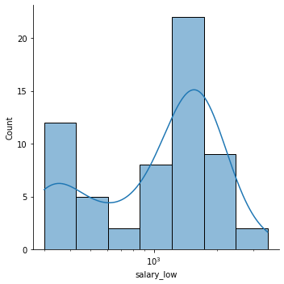

```python
%time sns.displot(df[df.weekly & df.salary_valid], x="salary_low", kde=True, log_scale=True)
```

## Daily

```
CPU times: user 593 ms, sys: 58.6 ms, total: 651 ms
Wall time: 550 ms
```

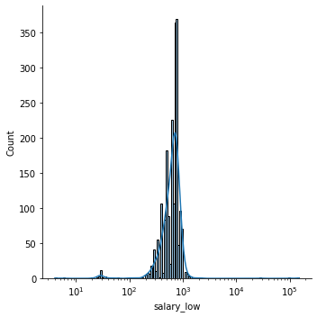

```python
%time sns.displot(df[df.daily], x="salary_low", kde=True, log_scale=True)
```

Mix of bad data and parsing

```python
df[df.daily & (df.salary_low > 3000)].sort_values('salary_low').T
```

|  | 73423 | 29338 | 32448 | 35501 |
| --- | --- | --- | --- | --- |
| title | Aboriginal Identified - Clerk General Scale - Cadetship Program - Various Locations - Temporary | Management Accountant - 9 day fortnight | Data Dev and Gov Analyst | Data Dev and Gov Analyst |
| description | ABOUT LEGAL AID NSW\nLegal Aid NSW is the largest legal aid agency in Australia, comprising of a Central Sydney office and 26 regional offices in ... | Our client is a high profile public-sector organisation located in the inner Bayside / Georges River Council suburban area within easy access of t... | Government agency looking for a to be a strong player in the implementation of a green field Big Data environment whilst cross-skilling with other... | Government agency looking for a to be a strong player in the implementation of a green field Big Data environment whilst cross-skilling with other... |
| uri | https://iworkfor.nsw.gov.au/job/aboriginal-identified-clerk-general-scale-cadetship-program-various-locations-temporary-212912 | https://www.seek.com.au/job/39843065 | https://jobs.launchrecruitment.com.au/job/100602033311507/data-dev-and-gov-analyst/ | https://jobs.launchrecruitment.com.au/job/100602033311507/data-dev-and-gov-analyst/ |
| view_date | 2020-10-21 22:35:08+00:00 | 2019-09-02 10:54:58 | 2020-05-26 20:13:28+00:00 | 2020-09-29 13:50:58+00:00 |
| org | Legal Aid Commission, Office of the | Pacific Search Partners | Launch Recruitment | Launch Recruitment |
| salary_raw | • Salary package of up to $27,700 including study and book allowances for a 60-day placement | Circa $100K + super for a 9 day/fortnight | $150000 - $180000 per day | $150000 - $180000 per day |
| salary_min | 27700 | 100000 | 150000 | 150000 |
| salary_max | NaN | NaN | 180000 | 180000 |
| salary_hours | 8 | 8 | 8 | 8 |
| location_raw | Sydney Region | Sydney, New South Wales, Australia | Parramatta, AU | Parramatta, AU |
| loc_id | 1.01932e+08 | 1.01932e+08 | 1.0205e+08 | 1.0205e+08 |
| loc_continent | Oceania | Oceania | Oceania | Oceania |
| loc_country | Australia | Australia | Australia | Australia |
| loc_county | Sydney | Sydney | Parramatta | Parramatta |
| loc_empire | Australia | Australia | Australia | Australia |
| loc_localadmin | Sydney | Sydney | None | None |
| loc_locality | Sydney | Sydney | None | None |
| loc_macrocounty | Sydney | Sydney | Sydney | Sydney |
| loc_region | New South Wales | New South Wales | New South Wales | New South Wales |
| processor | iworkfornsw | kaggle_promptcloud_latest | launchrecruitment | launchrecruitment |
| source | CC-MAIN-2020-45 | seekau_2019q3 | CC-MAIN-2020-24 | CC-MAIN-2020-40 |
| loc_neighbourhood | NaN | None | None | None |
| annual | False | False | False | False |
| weekly | False | False | False | False |
| daily | True | True | True | True |
| hourly | False | False | False | False |
| salary_low | 27700 | 100000 | 150000 | 150000 |
| salary_hi | NaN | NaN | 180000 | 180000 |
| salary_valid | True | True | True | True |
| pct_salary_range | NaN | NaN | 0.181818 | 0.181818 |

Many of these seem suss..

```python
df[df.daily & (df.salary_min < 100)].sort_values('salary_min', ascending=False).T
```

|  | 62595 | 71103 | 29321 | 35628 | 33287 | 34739 | 26735 | 32806 | 35832 | 32513 | 38755 | 34213 | 38782 | 65932 | 9808 | 35074 | 7886 | 33609 | 35842 | 28062 | 37935 | 64256 | 31186 | 31221 | 63834 | ... | 33639 | 33475 | 33466 | … |
| --- | --- | --- | --- | --- | --- | --- | --- | --- | --- | --- | --- | --- | --- | --- | --- | --- | --- | --- | --- | --- | --- | --- | --- | --- | --- | --- | --- | --- | --- | --- |
| title | PHP Developer | Development Services Officer | Child Protection Assessment Officer | Training Coordinator | Training Coordinator | Training Coordinator | Records and Scanning Administration Officers (work with a Qld Government dept) | Team Leader - Speak Out Program | Call Centre Operator | Call Centre Operator | Production Assistant | Team Leader - Speak Out Program | Warehouse Staff Needed | Customer Service Representative (Inbound) | Contact Centre Consultant\| HR Advice\|Payroll\|Casual Pool | Receptionist | Contact Centre Consultant\| HR Advice\|Payroll\|Casual Pool | Receptionist | Receptionist | Warehouse Operators | Assistant Educator | Forklift Driver - Day Shift | Packing Staff - Dairy Industry - Day and Afternoon Shift | Container Unloaders/General Labourers | Class 1 Driver - $20.50 per hour | ... | Scrum Master | Senior Release / Deployment Manager | Web Automation Test Specialist | … |
| description |  |  | BENEFITSDarlinghurst location 8 Month Temporary AssignmentChild protection THE COMPANYpeople2people are collaborating with the NSW Government who ... | Fantastic opportunity to work for a leading government agency who specialise in health and safety. Our client is undergoing a large scale transfor... | Fantastic opportunity to work for a leading government agency who specialise in health and safety. Our client is undergoing a large scale transfor... | Fantastic opportunity to work for a leading government agency who specialise in health and safety. Our client is undergoing a large scale transfor... | We are urgently seeking Records and Scanning Administration Officers with strong attention to detail to join our temporary team working with a pro... | Weave is seeking an experienced Team Leader to join the team.\nProviding leadership, support and coordination of Weave’s Speak Out Dual Diagnosis ... | Opportunity to work with a leading reputable government agency who are building a new online platform. This role will be shift work - 5 days per d... | Opportunity to work with a leading reputable government agency who are building a new online platform. This role will be shift work - 5 days per d... | We have a great opportunity for experienced Production Assistants to join a reputable printing organisation located in Craigieburn.\nOur client, l... | Weave is seeking an experienced Team Leader to join the team.\nProviding leadership, support and coordination of Weave’s Speak Out Dual Diagnosis ... | Labourforce has potions available for suitable candidates with our valued client based in Acacia Ridge due to increased work load, they are an ind... |  | About the company:\nOur client is a leading national organisation with a fantastic reputation for providing a valuable service to its customers an... | Join an exciting Receptionist role for one of our IT clients based in North Sydney for an initial 6 months contract with a view to extend. You wil... | About the company:\nOur client is a leading national organisation with a fantastic reputation for providing a valuable service to its customers an... | Join an exciting Receptionist role for one of our IT clients based in North Sydney for an initial 6 months contract with a view to extend. You wil... | Join an exciting Receptionist role for one of our IT clients based in North Sydney for an initial 6 months contract with a view to extend. You wil... | Warehouse Operators needed for ALDI Prestons Do you like a physically challenging role? About the company:Aldi have been operating in Australia si... | About Story House Early Learning:\nStory House Early Learning is an emerging early childhood provider with services in QLD, NSW and VIC. We strive... |  | Immediate Start Day Shift 5am - 3pm Afternoon Shift 2pm - 12am Ongoing Casual Shifts Mon - Friday Production and Warehouse work experience essenti... | Randstad is currently recruiting for casual container unloaders/general hands. As it is approaching closer to the silly season, our clients are ge... |  | ... | Join one of the largest IT clients based in Melbourne CBD for an initial 6 months contract for a Scrum Master role.\nMandatory skills needed:\n\nH... | Senior Release / Deployment Manager - Perth - Day Rate = $772.72 inc. Super\nScope:\n\nTracked and implemented deliverables against the scope and ... | Web Automation Test Specialist \| 6 month contract \| Circa - $750 inc. super per day\nThe Company:\nThis is a quintessential Australian household n... | … |
| uri | https://www.seek.com.au/job/36789537 | https://www.seek.com.au/job/37565087 | https://www.seek.com.au/job/40208499 | https://jobs.launchrecruitment.com.au/job/100602033335650/training-coordinator-2/ | https://jobs.launchrecruitment.com.au/job/100602033335650/training-coordinator-2/ | https://jobs.launchrecruitment.com.au/job/100602033335650/training-coordinator-2/ | https://www.seek.com.au/job/39934310 | https://jobs.launchrecruitment.com.au/job/100602033217942/team-leader-speak-out-program/ | https://jobs.launchrecruitment.com.au/job/100602033372517/call-centre-operator-1/ | https://jobs.launchrecruitment.com.au/job/100602033372517/call-centre-operator-1/ | https://www.seek.com.au/job/50994456?type=standard | https://jobs.launchrecruitment.com.au/job/100602033217942/team-leader-speak-out-program/ | https://www.seek.com.au/job/50995587?type=standard | https://www.seek.com.au/job/37203654 | https://www.davidsonwp.com/job/100562133333296/contact-centre-consultant-hr-advice-payroll-casual-pool/ | https://jobs.launchrecruitment.com.au/job/100602033373812/receptionist-9/ | https://www.davidsonwp.com/job/100562133333296/contact-centre-consultant-hr-advice-payroll-casual-pool/ | https://jobs.launchrecruitment.com.au/job/100602033373812/receptionist-9/ | https://jobs.launchrecruitment.com.au/job/100602033373812/receptionist-9/ | https://www.seek.com.au/job/40269764 | https://www.seek.com.au/job/50783642?cid=SKL-CareerGuide | https://www.seek.com.au/job/37439153 | https://www.seek.com.au/job/39950345 | https://www.seek.com.au/job/40162654 | https://www.seek.co.nz/job/37434117 | ... | https://jobs.launchrecruitment.com.au/job/100602033376518/scrum-master-4/ | https://jobs.launchrecruitment.com.au/job/100602033362452/senior-release-slash-deployment-manager/ | https://jobs.launchrecruitment.com.au/job/100602033361046/web-automation-test-specialist/ | … |
| view_date | 2018-07-24 08:36:19 | 2018-10-26 04:21:31 | 2019-10-21 08:22:12 | 2020-09-24 03:55:28+00:00 | 2020-07-07 14:34:53+00:00 | 2020-03-29 22:32:56+00:00 | 2019-09-13 05:47:40 | 2020-07-05 07:01:30+00:00 | 2020-09-29 13:37:04+00:00 | 2020-05-29 16:02:55+00:00 | 2020-12-03 21:24:56+00:00 | 2020-04-04 07:15:18+00:00 | 2020-12-02 01:03:33+00:00 | 2018-09-13 00:55:45 | 2020-10-20 20:16:51+00:00 | 2020-03-29 23:10:58+00:00 | 2020-08-08 10:27:12+00:00 | 2020-07-14 22:43:41+00:00 | 2020-09-25 19:11:59+00:00 | 2019-10-29 05:31:44 | 2020-11-27 18:14:20+00:00 | 2018-10-11 00:40:16 | 2019-09-16 05:38:03 | 2019-10-15 07:52:12 | 2018-10-11 01:56:36 | ... | 2020-07-07 15:40:26+00:00 | 2020-07-03 03:06:52+00:00 | 2020-07-05 22:55:47+00:00 | … |
| org | Chandler Macleod Group | Smalls, GWS & JHA trading as Spinifex Recruiting | people2people | Launch Recruitment | Launch Recruitment | Launch Recruitment | Recruitment@Top | Launch Recruitment | Launch Recruitment | Launch Recruitment | Staff Australia Recruitment Services P/L | Launch Recruitment | Labourforce | Kelly Services | Davidson | Launch Recruitment | Davidson | Launch Recruitment | Launch Recruitment | IPA | Story House Early Learning | HORNER Recruitment | Dekro Recruitment | Randstad - Industrial | Adecco Transport & Logistics | ... | Launch Recruitment | Launch Recruitment | Launch Recruitment | … |
| salary_raw | $60 - $70 p.d. + Super | $50 - $60 p.d. + Super | $45.00 per day | $35 - $38 per day | $35 - $38 per day | $35 - $38 per day | Casual $30.19(day shift)- $33.81(afternoon shift) | * Part Time - 9 day fortnight (until 30 June 2019) | $30 - $32 per day | $30 - $32 per day | $30 - $32 p.d. | * Part Time - 9 day fortnight (until 30 June 2019) | $27.17 DAY $29.30 ARVO | $28.06 p.d. + Super | $28 per day | $28 - $30 per day | $28 per day | $28 - $30 per day | $28 - $30 per day | $27.33 - $28.33 p.d. | $27.21 - $28.03 + super + uniform + PD | $26 - $27 per day | Day Shift $25.07 Afternoon Shift $28.83+ Super | $25 - $30 p.d. | $20 - $21 p.d. + Over time | ... | $0 - $700 per day | $0 - $772.72 per day | $0 - $760 per day | … |
| salary_min | 60 | 50 | 45 | 35 | 35 | 35 | 30.19 | 30 | 30 | 30 | 30 | 30 | 29.3 | 28.06 | 28 | 28 | 28 | 28 | 28 | 27.33 | 27.21 | 26 | 25.07 | 25 | 20 | ... | 0 | 0 | 0 | … |
| salary_max | 70 | 60 | NaN | 38 | 38 | 38 | NaN | NaN | 32 | 32 | 32 | NaN | NaN | NaN | NaN | 30 | NaN | 30 | 30 | 28.33 | 28.03 | 27 | NaN | 30 | 21 | ... | 700 | 772.72 | 760 | … |
| salary_hours | 8 | 8 | 8 | 8 | 8 | 8 | 8 | 8 | 8 | 8 | 8 | 8 | 8 | 8 | 8 | 8 | 8 | 8 | 8 | 8 | 8 | 8 | 8 | 8 | 8 | ... | 8 | 8 | 8 | … |
| location_raw | Sydney, CBD, Inner West & Eastern Suburbs, AU | Sydney, Parramatta & Western Suburbs, AU | Sydney, New South Wales, Australia | Melbourne, AU | Melbourne, AU | Melbourne, AU | Brisbane, Queensland, Australia | Sydney, AU | Geelong, AU | Geelong, AU | craigieburn, Melbourne, Victoria, Australia | Sydney, AU | acaciaridge, Brisbane, Queensland, Australia | Sydney, South West & M5 Corridor, AU | Brisbane, AU | Melbourne, AU | Brisbane, AU | Melbourne, AU | Melbourne, AU | Sydney, New South Wales, Australia | mascot, Sydney, New South Wales, Australia | Melbourne, Bayside & South Eastern Suburbs, AU | Melbourne, Victoria, Australia | Melbourne, Victoria, Australia | Auckland, Manukau & East Auckland, NZ | ... | Melbourne, AU | Perth, AU | Sydney, AU | … |
| loc_id | 8.57823e+07 | 1.01932e+08 | 1.01932e+08 | 1.01933e+08 | 1.01933e+08 | 1.01933e+08 | 1.01934e+08 | 1.01932e+08 | 1.01933e+08 | 1.01933e+08 | 1.01933e+08 | 1.01932e+08 | 1.01934e+08 | 8.57744e+07 | 1.01934e+08 | 1.01933e+08 | 1.01934e+08 | 1.01933e+08 | 1.01933e+08 | 1.01932e+08 | 1.01931e+08 | 1.01933e+08 | 1.01933e+08 | 1.01933e+08 | 1.12598e+09 | ... | 1.01933e+08 | 1.01938e+08 | 1.01932e+08 | … |
| loc_continent | Oceania | Oceania | Oceania | Oceania | Oceania | Oceania | Oceania | Oceania | Oceania | Oceania | Oceania | Oceania | Oceania | Oceania | Oceania | Oceania | Oceania | Oceania | Oceania | Oceania | Oceania | Oceania | Oceania | Oceania | Oceania | ... | Oceania | Oceania | Oceania | … |
| loc_country | Australia | Australia | Australia | Australia | Australia | Australia | Australia | Australia | Australia | Australia | Australia | Australia | Australia | Australia | Australia | Australia | Australia | Australia | Australia | Australia | Australia | Australia | Australia | Australia | New Zealand | ... | Australia | Australia | Australia | … |
| loc_county | Melbourne | Sydney | Sydney | Melbourne | Melbourne | Melbourne | Brisbane | Sydney | Greater Geelong | Greater Geelong | Hume | Sydney | Brisbane | Sydney | Brisbane | Melbourne | Brisbane | Melbourne | Melbourne | Sydney | Botany Bay | Melbourne | Melbourne | Melbourne | Auckland | ... | Melbourne | Perth | Sydney | … |
| loc_empire | Australia | Australia | Australia | Australia | Australia | Australia | Australia | Australia | Australia | Australia | Australia | Australia | Australia | Australia | Australia | Australia | Australia | Australia | Australia | Australia | Australia | Australia | Australia | Australia | None | ... | Australia | Australia | Australia | … |
| loc_localadmin | Melbourne | Sydney | Sydney | Melbourne | Melbourne | Melbourne | Brisbane City | Sydney | Geelong | Geelong | Craigieburn | Sydney | Brisbane City | Sydney | Brisbane City | Melbourne | Brisbane City | Melbourne | Melbourne | Sydney | Mascot | Melbourne | Melbourne | Melbourne | None | ... | Melbourne | Perth | Sydney | … |
| loc_locality | Melbourne | Sydney | Sydney | Melbourne | Melbourne | Melbourne | Brisbane City | Sydney | Geelong | Geelong | Craigieburn | Sydney | Brisbane City | Sydney | Brisbane City | Melbourne | Brisbane City | Melbourne | Melbourne | Sydney | Mascot | Melbourne | Melbourne | Melbourne | Manukau City | ... | Melbourne | Perth | Sydney | … |
| loc_macrocounty | Melbourne | Sydney | Sydney | Melbourne | Melbourne | Melbourne | Brisbane | Sydney | Geelong | Geelong | Melbourne | Sydney | Brisbane | Sydney | Brisbane | Melbourne | Brisbane | Melbourne | Melbourne | Sydney | Sydney | Melbourne | Melbourne | Melbourne | None | ... | Melbourne | Perth | Sydney | … |
| loc_region | Victoria | New South Wales | New South Wales | Victoria | Victoria | Victoria | Queensland | New South Wales | Victoria | Victoria | Victoria | New South Wales | Queensland | New South Wales | Queensland | Victoria | Queensland | Victoria | Victoria | New South Wales | New South Wales | Victoria | Victoria | Victoria | Auckland Region | ... | Victoria | Western Australia | New South Wales | … |
| processor | kaggle_promptcloud_listings | kaggle_promptcloud_listings | kaggle_promptcloud_latest | launchrecruitment | launchrecruitment | launchrecruitment | kaggle_promptcloud_latest | launchrecruitment | launchrecruitment | launchrecruitment | seek | launchrecruitment | seek | kaggle_promptcloud_listings | davidsonwp | launchrecruitment | davidsonwp | launchrecruitment | launchrecruitment | kaggle_promptcloud_latest | seek | kaggle_promptcloud_listings | kaggle_promptcloud_latest | kaggle_promptcloud_latest | kaggle_promptcloud_listings | ... | launchrecruitment | launchrecruitment | launchrecruitment | … |
| source | seekau | seekau | seekau_2019q3 | CC-MAIN-2020-40 | CC-MAIN-2020-29 | CC-MAIN-2020-16 | seekau_2019q3 | CC-MAIN-2020-29 | CC-MAIN-2020-40 | CC-MAIN-2020-24 | CC-MAIN-2020-50 | CC-MAIN-2020-16 | CC-MAIN-2020-50 | seekau | CC-MAIN-2020-45 | CC-MAIN-2020-16 | CC-MAIN-2020-34 | CC-MAIN-2020-29 | CC-MAIN-2020-40 | seekau_2019q3 | CC-MAIN-2020-50 | seekau | seekau_2019q3 | seekau_2019q3 | seekau | ... | CC-MAIN-2020-29 | CC-MAIN-2020-29 | CC-MAIN-2020-29 | … |
| loc_neighbourhood | Melbourne CBD | None | None | None | None | None | None | None | None | None | None | None | None | Sydney South | None | None | None | None | None | None | None | None | None | None | None | ... | None | None | None | … |
| annual | False | False | False | False | False | False | False | False | False | False | False | False | False | False | False | False | False | False | False | False | False | False | False | False | False | ... | False | False | False | … |
| weekly | False | False | False | False | False | False | False | False | False | False | False | False | False | False | False | False | False | False | False | False | False | False | False | False | False | ... | False | False | False | … |
| daily | True | True | True | True | True | True | True | True | True | True | True | True | True | True | True | True | True | True | True | True | True | True | True | True | True | ... | True | True | True | … |
| hourly | False | False | False | False | False | False | False | False | False | False | False | False | False | False | False | False | False | False | False | False | False | False | False | False | False | ... | False | False | False | … |
| salary_low | 60 | 50 | 45 | 35 | 35 | 35 | 30.19 | 30 | 30 | 30 | 30 | 30 | 29.3 | 28.06 | 28 | 28 | 28 | 28 | 28 | 27.33 | 27.21 | 26 | 25.07 | 25 | 20 | ... | 700 | 772.72 | 760 | … |
| salary_hi | 70 | 60 | NaN | 38 | 38 | 38 | NaN | NaN | 32 | 32 | 32 | NaN | NaN | NaN | NaN | 30 | NaN | 30 | 30 | 28.33 | 28.03 | 27 | NaN | 30 | 21 | ... | NaN | NaN | NaN | … |
| salary_valid | True | True | True | True | True | True | True | True | True | True | True | True | True | True | True | True | True | True | True | True | True | True | True | True | True | ... | True | True | True | … |
| pct_salary_range | 0.153846 | 0.181818 | NaN | 0.0821918 | 0.0821918 | 0.0821918 | NaN | NaN | 0.0645161 | 0.0645161 | 0.0645161 | NaN | NaN | NaN | NaN | 0.0689655 | NaN | 0.0689655 | 0.0689655 | 0.0359324 | 0.0296886 | 0.0377358 | NaN | 0.181818 | 0.0487805 | ... | NaN | NaN | NaN | … |

30 rows × 295 columns

```python
SALARY_DAILY_MAX_AUD = 3000
```

```python
SALARY_DAILY_MIN_AUD = 100
```

```python
df.loc[df.daily & (df.salary_low < SALARY_DAILY_MIN_AUD), "salary_valid"] = False
```

```python
df.loc[df.daily & (df.salary_low > SALARY_DAILY_MAX_AUD), "salary_valid"] = False
```

```
CPU times: user 374 ms, sys: 69.6 ms, total: 444 ms
Wall time: 343 ms
```

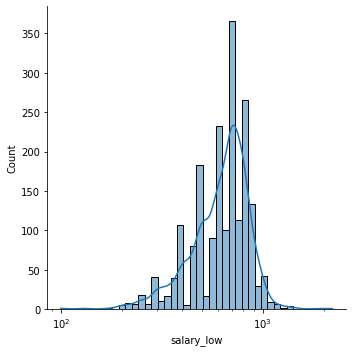

```python
%time sns.displot(df[df.salary_valid & df.daily], x="salary_low", kde=True, log_scale=True)
```

## Hourly

```
CPU times: user 954 ms, sys: 60.7 ms, total: 1.01 s
Wall time: 897 ms
```

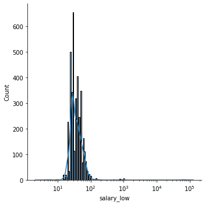

```python
%time sns.displot(df[df.hourly], x="salary_low", kde=True, log_scale=True)
```

Bad parsing and bad data

```python
df[df.hourly & (df.salary_low > 250)].sort_values("salary_low").T
```

|  | 5238 | 8787 | 70468 | 212 | 9041 | 9107 | 51798 | 30332 | 30199 | 27985 | 24474 | 24053 | 19691 | 69134 | 26038 | 53100 | 53139 | 19659 | 65741 | 40904 | 70924 |
| --- | --- | --- | --- | --- | --- | --- | --- | --- | --- | --- | --- | --- | --- | --- | --- | --- | --- | --- | --- | --- | --- |
| title | Strategic Innovation Manager - National Initiatives and Performance | Strategic Innovation Manager - National Initiatives and Performance | PERSONAL CARE ASSISTANT | Senior Business Implementation Consultant | Business Implementation Consultant | Senior Business Implementation Consultant | Children's Services Officer - Room Leader | Retail Assistants Wanted - Sales & Promotions! | Hospitality Workers - Promotion People Wanted! | Customer Service And Marketing Consultants Wanted! Immediate Starts Available! | Campaign Managers Wanted! New Summer Sales Campaigns About To Begin! | Retail Assistants Wanted - Promotion Sales! | Financial Counsellor (Integrated Services Project) | Spray Painter- Kitchens | Mid-Level Finished Artist | Radiographers (Shift) - Medical Imaging Department, Cairns | Radiographers (Shift) - Medical Imaging Department, Cairns | Community Lawyer (Integrated Services Project) | Leading Hand | F45 Head Coach / Trainer | Senior Contract Administrator |
| description | About the Role\nThe main purpose of this role is to manage the implementation of the Catalyst Lab Innovation Program which aims to support the ide... | About the Role\nThe main purpose of this role is to manage the implementation of the Catalyst Lab Innovation Program which aims to support the ide... |  | Our client is a major insurance organisation that is well recognized in the industry. They provide innovative, competitive and flexible solutions ... | Our client is a major insurance organisation that is well recognized in the industry. They provide innovative, competitive and flexible solutions ... | Our client is a major insurance organisation that is well recognized in the industry. They provide innovative, competitive and flexible solutions ... | Full Time Scone The Role: Council is seeking an energetic and enthusiastic individual to undertake the above position. The successful candidate w... | Our client, HQ Direct are looking for individuals who have huge personalities to employ their skills to the fast paced and highly social face to f... | Our client, HQ Direct are looking for individuals who have huge personalities to employ their skills to the fast paced and highly social face to f... | Wow Recruitment is on the hunt for social and bubbly guys and girls to join our client’s team. HQ Direct are launching some brand-new promotional ... | POP Advertising is looking for the next wave of campaign managers and sales agents to kickstart our new summer campaigns. We are looking for indiv... | Our client, HQ Direct are looking for individuals who have huge personalities to employ their skills to the fast paced and highly social face to f... | About the role\n18 hours per week – 12 month fixed term, based in Fitzroy, Victoria\nSocial Security Rights Victoria and the Financial and Consume... | Spray Painter Required. Our family run property services business, based on the North Side of Brisbane is currently looking for a experienced 2 Pa... | At the Y, we believe in the power of inspired young people. A community not-for-profit organisation with 17 million participations annually across... |  |  | About the role\n30.4 hours per week – 12 month fixed term, based in Fitzroy, Victoria\nSocial Security Rights Victoria and the Financial and Consu... |  | JOIN SYDNEY’S PREMIER F45 STUDIO!\nApply for this role at www.bit.ly/F45job\nDo you get freakin' excited and pride yourself on providing fun, fres... |  |
| uri | https://www.davidsonwp.com/job/100562133239422/strategic-innovation-manager-national-initiatives-and-performance-1/ | https://www.davidsonwp.com/job/100562133239422/strategic-innovation-manager-national-initiatives-and-performance/ | https://www.seek.com.au/job/37565380 | https://www.davidsonwp.com/job/100562133256145/senior-business-implementation-consultant-1/ | https://www.davidsonwp.com/job/100562133253698/business-implementation-consultant/ | https://www.davidsonwp.com/job/100562133256145/senior-business-implementation-consultant-1/ | https://www.seek.com.au/job/36025488 | https://www.seek.com.au/job/40047761 | https://www.seek.com.au/job/39944385 | https://www.seek.com.au/job/39835797 | https://www.seek.com.au/job/40101847 | https://www.seek.com.au/job/40201201 | https://probonoaustralia.com.au/jobs/2019/11/financial-counsellor-integrated-services-project/ | https://www.seek.com.au/job/36166736 | https://www.seek.com.au/job/40071743 | https://www.seek.com.au/job/37116531 | https://www.seek.com.au/job/37116530 | https://probonoaustralia.com.au/jobs/2019/11/community-lawyer-integrated-services-project/ | https://www.seek.com.au/job/37209437 | https://www.seek.com.au/job/50749266?type=promoted | https://www.seek.com.au/job/37565417 |
| view_date | 2020-09-18 15:51:42+00:00 | 2020-10-19 05:08:00+00:00 | 2018-10-26 04:23:32 | 2020-05-27 20:05:51+00:00 | 2020-10-19 05:03:28+00:00 | 2020-10-22 04:58:01+00:00 | 2018-04-20 04:32:01 | 2019-09-28 08:41:44 | 2019-09-15 09:15:28 | 2019-09-01 07:04:43 | 2019-10-05 11:57:46 | 2019-10-19 07:56:47 | 2020-07-13 21:58:47+00:00 | 2018-05-09 04:42:46 | 2019-10-02 09:35:09 | 2018-09-02 00:36:35 | 2018-09-02 00:38:14 | 2020-07-13 21:35:19+00:00 | 2018-09-13 01:53:15 | 2020-10-30 20:01:37+00:00 | 2018-10-26 04:06:21 |
| org | Davidson | Davidson | Upper Hunter Shire Council | Davidson | Davidson | Davidson | Upper Hunter Shire Council | Wow Recruitment | Wow Recruitment | Wow Recruitment | Wow Recruitment | Wow Recruitment | Social Security Rights Victoria | Regen Resurfacing PTY LTD | YMCA Victoria | Cairns & Hinterland Hospital and Health Service | Cairns & Hinterland Hospital and Health Service | Social Security Rights Victoria | Design & Build | F45 Training Artarmon | Hays Construction |
| salary_raw | $500 per day, Benefits: 7 hour day, 35 hour week with State Government. | $500 per day, Benefits: 7 hour day, 35 hour week with State Government. | $781.40 - $830.50 per 38 hour week | $800 - $1000 per hour | $800 - $1000 per hour | $800 - $1000 per hour | $972.10 - $1088.80 per 38 hour week | Hourly rate + Super + Bonuses OTE $1000 - $1800 | Hourly rate + Super + Bonuses OTE $1000 - $1800 | Hourly rate + Super + Bonuses OTE $1000 - $1800 | $24.37/hour + Super + Bonuses OTE $1000 - $1800 PW | Hourly rate + Super + Bonuses OTE $1000 - $1800 | $36,000-$38,500 (for 18 hour week) | $50,000 - $54,999 plus super + Vehicle & Mobile Ph | $62,936 - $70,682 per hour + super | $64287 - $97438 p.h. | $64287 - $97438 p.h. | $67,000-$70,000 for 30.4 hour week | $80 - $100k or hourly rate | Competitive hourly rate plus commission (OTE 90k) | $130000.00 - $150000.00 p.h. + +Super |
| salary_min | 500 | 500 | 781.4 | 800 | 800 | 800 | 972.1 | 1000 | 1000 | 1000 | 1000 | 1000 | 36000 | 50000 | 62936 | 64287 | 64287 | 67000 | 80000 | 90000 | 130000 |
| salary_max | NaN | NaN | 830.5 | 1000 | 1000 | 1000 | 1088.8 | 1800 | 1800 | 1800 | 1800 | 1800 | 38500 | 54999 | 70682 | 97438 | 97438 | 70000 | 100000 | NaN | 150000 |
| salary_hours | 1 | 1 | 1 | 1 | 1 | 1 | 1 | 1 | 1 | 1 | 1 | 1 | 1 | 1 | 1 | 1 | 1 | 1 | 1 | 1 | 1 |
| location_raw | Parramatta, AU | Parramatta, AU | Newcastle, Maitland & Hunter, AU | Melbourne, AU | Melbourne, AU | Melbourne, AU | Newcastle, Maitland & Hunter, AU | Melbourne, Victoria, Australia | Melbourne, Victoria, Australia | Melbourne, Victoria, Australia | Sydney, New South Wales, Australia | Melbourne, Victoria, Australia | Melbourne(Fitzroy) | Brisbane, CBD & Inner Suburbs, AU | Melbourne, Victoria, Australia | Cairns & Far North, AU | Cairns & Far North, AU | Melbourne(Fitzroy) | Melbourne, CBD & Inner Suburbs, AU | lanecovenorth, Sydney, New South Wales, Australia | Newcastle, Maitland & Hunter, AU |
| loc_id | 1.0205e+08 | 1.0205e+08 | 4.04539e+08 | 1.01933e+08 | 1.01933e+08 | 1.01933e+08 | 4.04539e+08 | 1.01933e+08 | 1.01933e+08 | 1.01933e+08 | 1.01932e+08 | 1.01933e+08 | 1.01933e+08 | 8.57823e+07 | 1.01933e+08 | 1.02079e+08 | 1.02079e+08 | 1.01933e+08 | 8.57823e+07 | 1.01932e+08 | 4.04539e+08 |
| loc_continent | Oceania | Oceania | Oceania | Oceania | Oceania | Oceania | Oceania | Oceania | Oceania | Oceania | Oceania | Oceania | Oceania | Oceania | Oceania | Oceania | Oceania | Oceania | Oceania | Oceania | Oceania |
| loc_country | Australia | Australia | Australia | Australia | Australia | Australia | Australia | Australia | Australia | Australia | Australia | Australia | Australia | Australia | Australia | New Zealand | New Zealand | Australia | Australia | Australia | Australia |
| loc_county | Parramatta | Parramatta | Greater Bendigo | Melbourne | Melbourne | Melbourne | Greater Bendigo | Melbourne | Melbourne | Melbourne | Sydney | Melbourne | Yarra | Melbourne | Melbourne | Far North District | Far North District | Yarra | Melbourne | Sydney | Greater Bendigo |
| loc_empire | Australia | Australia | Australia | Australia | Australia | Australia | Australia | Australia | Australia | Australia | Australia | Australia | Australia | Australia | Australia | None | None | Australia | Australia | Australia | Australia |
| loc_localadmin | None | None | Hunter | Melbourne | Melbourne | Melbourne | Hunter | Melbourne | Melbourne | Melbourne | Sydney | Melbourne | Fitzroy | Melbourne | Melbourne | None | None | Fitzroy | Melbourne | Sydney | Hunter |
| loc_locality | None | None | None | Melbourne | Melbourne | Melbourne | None | Melbourne | Melbourne | Melbourne | Sydney | Melbourne | Fitzroy | Melbourne | Melbourne | None | None | Fitzroy | Melbourne | Sydney | None |
| loc_macrocounty | Sydney | Sydney | None | Melbourne | Melbourne | Melbourne | None | Melbourne | Melbourne | Melbourne | Sydney | Melbourne | Melbourne | Melbourne | Melbourne | None | None | Melbourne | Melbourne | Sydney | None |
| loc_region | New South Wales | New South Wales | Victoria | Victoria | Victoria | Victoria | Victoria | Victoria | Victoria | Victoria | New South Wales | Victoria | Victoria | Victoria | Victoria | Northland Region | Northland Region | Victoria | Victoria | New South Wales | Victoria |
| processor | davidsonwp | davidsonwp | kaggle_promptcloud_listings | davidsonwp | davidsonwp | davidsonwp | kaggle_promptcloud_listings | kaggle_promptcloud_latest | kaggle_promptcloud_latest | kaggle_promptcloud_latest | kaggle_promptcloud_latest | kaggle_promptcloud_latest | probono | kaggle_promptcloud_listings | kaggle_promptcloud_latest | kaggle_promptcloud_listings | kaggle_promptcloud_listings | probono | kaggle_promptcloud_listings | seek | kaggle_promptcloud_listings |
| source | CC-MAIN-2020-40 | CC-MAIN-2020-45 | seekau | CC-MAIN-2020-24 | CC-MAIN-2020-45 | CC-MAIN-2020-45 | seekau | seekau_2019q3 | seekau_2019q3 | seekau_2019q3 | seekau_2019q3 | seekau_2019q3 | CC-MAIN-2020-29 | seekau | seekau_2019q3 | seekau | seekau | CC-MAIN-2020-29 | seekau | CC-MAIN-2020-45 | seekau |
| loc_neighbourhood | None | None | None | None | None | None | None | None | None | None | None | None | None | Melbourne CBD | None | None | None | None | Melbourne CBD | None | None |
| annual | False | False | False | False | False | False | False | False | False | False | False | False | False | False | False | False | False | False | False | False | False |
| weekly | False | False | False | False | False | False | False | False | False | False | False | False | False | False | False | False | False | False | False | False | False |
| daily | False | False | False | False | False | False | False | False | False | False | False | False | False | False | False | False | False | False | False | False | False |
| hourly | True | True | True | True | True | True | True | True | True | True | True | True | True | True | True | True | True | True | True | True | True |
| salary_low | 500 | 500 | 781.4 | 800 | 800 | 800 | 972.1 | 1000 | 1000 | 1000 | 1000 | 1000 | 36000 | 50000 | 62936 | 64287 | 64287 | 67000 | 80000 | 90000 | 130000 |
| salary_hi | NaN | NaN | 830.5 | 1000 | 1000 | 1000 | 1088.8 | 1800 | 1800 | 1800 | 1800 | 1800 | 38500 | 54999 | 70682 | 97438 | 97438 | 70000 | 100000 | NaN | 150000 |
| salary_valid | True | True | True | True | True | True | True | True | True | True | True | True | True | True | True | True | True | True | True | True | True |
| pct_salary_range | NaN | NaN | 0.0609219 | 0.222222 | 0.222222 | 0.222222 | 0.113251 | 0.571429 | 0.571429 | 0.571429 | 0.571429 | 0.571429 | 0.0671141 | 0.09522 | 0.115942 | 0.409968 | 0.409968 | 0.0437956 | 0.222222 | NaN | 0.142857 |

```python
SALARY_HOURLY_MAX_AUD = 300
```

```python
df.loc[df.hourly & (df.salary_low > SALARY_HOURLY_MAX_AUD), "salary_valid"] = False
```

```
CPU times: user 347 ms, sys: 49.8 ms, total: 397 ms
Wall time: 295 ms
```

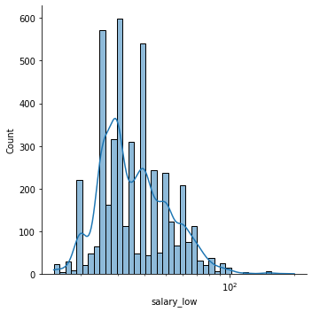

```python
%time sns.displot(df[df.hourly & df.salary_valid], x="salary_low", kde=True, log_scale=True)
```

# Inferring Period

It's easy to separate annual from everything else

Weekly is pretty rare.

There's some overlap between hourly and daily.

```python
SALARY_MIN_AUD, SALARY_HOURLY_MAX_AUD, SALARY_MIN_AUD*2000, SALARY_HOURLY_MAX_AUD*2000
```

```
(15, 300, 30000, 600000)
```

```python
SALARY_DAILY_MIN_AUD, SALARY_DAILY_MAX_AUD, SALARY_DAILY_MIN_AUD*250, SALARY_DAILY_MAX_AUD*250
```

```
(100, 3000, 25000, 750000)
```

```python
SALARY_WEEKLY_MIN_AUD, SALARY_WEEKLY_MAX_AUD, SALARY_WEEKLY_MIN_AUD*50, SALARY_WEEKLY_MAX_AUD*50
```

```
(300, 5000, 15000, 250000)
```

```python
SALARY_ANNUAL_MIN_AUD, SALARY_MAX_AUD
```

```
(20000, 500000)
```

```python
df[df.salary_valid].groupby("salary_hours").agg(min=('salary_low', 'min'), max=('salary_low', 'max'), n=('salary_low', 'count'))
```

| salary_hours | min | max | n |
| --- | --- | --- | --- |
| 1.0 | 15.0 | 200.0 | 4390 |
| 8.0 | 100.0 | 2200.0 | 1945 |
| 40.0 | 300.0 | 3500.0 | 60 |
| 2000.0 | 20000.0 | 455245.0 | 5777 |

```python
len(df[df.salary_low.between(100, 200) & df.salary_valid & (~df.hourly) & (~df.daily)])
```

```
17
```

```python
ANNUAL_HOURS = 2000
WEEKLY_HOURS = 40
DAILY_HOURS = 8
HOURLY_HOURS = 1

salary_periods = {
    (SALARY_ANNUAL_MIN_AUD, SALARY_MAX_AUD): ANNUAL_HOURS,
    # Exclude as is quite rare
    #(SALARY_WEEKLY_MIN_AUD, SALARY_WEEKLY_MAX_AUD): WEEKLY_HOURS,
    (SALARY_DAILY_MIN_AUD, SALARY_DAILY_MAX_AUD): DAILY_HOURS,
    (SALARY_MIN_AUD, SALARY_HOURLY_MAX_AUD): HOURLY_HOURS,
}
```

```python
def infer_salary_hours(salary):
    possible_periods = [(low, hi) for (low, hi) in salary_periods if low < salary < hi]
    if len(possible_periods) == 1:
        return salary_periods[possible_periods[0]]
    # Ambiguous or no match
```

Too high

```python
infer_salary_hours(500_000)
```

```python
infer_salary_hours(20_000)
```

Between annual and daily

```python
infer_salary_hours(3_000)
```

Daily

```python
infer_salary_hours(300)
```

```
8
```

Ambiguous: Could between hourly and daily

```python
infer_salary_hours(200)
```

Hourly

```python
infer_salary_hours(100)
```

```
1
```

```python
df['inferred_salary_hours'] = np.nan
```

```python
df.loc[df.salary_valid, 'inferred_salary_hours'] = df.salary_hours
```

```python
df.loc[df.salary_valid & df.inferred_salary_hours.isna(), 'inferred_salary_hours'] = df.salary_min.apply(infer_salary_hours)
```

```python
sum(~df.salary_hours.isna()), sum(~df.inferred_salary_hours.isna())
```

```
(13808, 21308)
```

```python
df.inferred_salary_hours.value_counts().to_frame()
```

|  | inferred_salary_hours |
| --- | --- |
| 2000.0 | 14596 |
| 1.0 | 4606 |
| 8.0 | 2046 |
| 40.0 | 60 |

```python
df['annual_salary'] = (df['salary_low'] * 2000/df['inferred_salary_hours']).astype('float64')
```

```python
df[~df.annual_salary.isna()].sort_values('annual_salary').T
```

|  | 21604 | 63681 | 63662 | 63827 | 63833 | 63693 | 64234 | 64706 | 63502 | 64235 | 23120 | 21684 | 20546 | 31633 | 67952 | 63864 | 63333 | 33858 | 35338 | 30703 | 56429 | 30197 | 6373 | 66502 | 40723 | ... | 6672 | 6676 | 16060 | … |
| --- | --- | --- | --- | --- | --- | --- | --- | --- | --- | --- | --- | --- | --- | --- | --- | --- | --- | --- | --- | --- | --- | --- | --- | --- | --- | --- | --- | --- | --- | --- |
| title | Sales Specialists \| Earner Exceed $AUD 2000 weekly \| Apply Now! | 2019 Aboriginal and Torres Strait Islander Childrens Services Traineeship | 2019 Childrens Services Traineeship for Persons with a Disability | 2019 Business Administration Traineeships | 2019 Childrens Services Traineeship | 2019 Childrens Services Traineeship | 2019 Information Technology Traineeships for Persons with a Disability | 2019 Business Administration Traineeships for Persons with a Disability | 2019 Business Administration Traineeships for Persons with a Disability | 2019 Business Administration Traineeships | IT Support Technician Traineeship | Aupair required Mosman Full-time hours $400 per week | Non Executive Director | Apprentice Plumber | Graphic Designer - Fixed Term | Travel & Tourism Tutor | Senior Hair Stylist | Amazing Job 7 expired | Amazing Job 7 expired | Full-Time Legal Receptionist & Conveyancing Assistant | Air-Conditioning Trade Assistant | Junior Warehouse | 2 x Java Developers | Test Analyst | Part Time Sports Coach | ... | Corporate Services Executive | Strategy & Performance Executive | Fire Safety SME - Transport | … |
| description | A great business opportunity, with UNLIMITED COMMISSIONS,UNCAPPED!\nIf you’ve got the skills and you’re ready to work with agrowing, dynamic compa... |  |  |  |  |  |  |  |  |  | Xenontech is the Premier IT Support Company for NSW Schools. Xenontech is offering an exciting opportunity for any aspiring Desktop/Network Suppor... | Mother’s help/ au pair required for two girls 2 and 4.\nFull-time hours required.\nCall or text Amy\n6981 + click to reveal\nREVEAL_DETAILS\n | About the role\nWorkways Australia Ltd is seeking applications from suitably qualified people with a passion for making a positive social impact i... | QBuild invites applications for plumbing apprenticeship positions in the following locations to commence in March 2020: Apprentice Plumber - Rockh... |  |  |  | This Amazing Job will change your life.\nTe labores probatus vis, equidem offendit ius ex. Ea latine rationibus eos, at modus vocent ullamcorper m... | This Amazing Job will change your life.\nTe labores probatus vis, equidem offendit ius ex. Ea latine rationibus eos, at modus vocent ullamcorper m... | Applications are invited for the position of a full-time Legal Receptionist and Conveyancing Assistant. (Monday - Friday 8.15 am - 4.45 pm) Candi... |  | About the business Contract coffee roasting business located in Clayton. About the role Enthusiastic, friendly, reliable, trustworthy person w... | About the Company\nJ oin a global company putting technology at their forefront! They’re looking to grow out they’re Brisbane team and give you th... |  | Due to increased demands in our sporting and educational programs we are seeking up to three permanent-part time Sports Coach for 2021 (up to 20 h... | ... | Brisbane Catholic Education is committed to learning outcomes for over 72,000 young people in 141 Schools across the South East Queensland. Ingrai... | Brisbane Catholic Education is committed to learning outcomes for over 72,000 young people in 141 Schools across south-east Queensland. Ingrained ... | Fire Safety Engineering SME required to work on iconic rail / tunnelling projects in Sydney.\nScope of engagement:\nAct as an SME for all Fire Lif... | … |
| uri | https://www.gumtree.com.au/s-ad/baulkham-hills/sales-representative-consultant/sales-specialists-earner-exceed-aud-2000-weekly-apply-now-/1244428014 | https://www.seek.com.au/job/37437336 | https://www.seek.com.au/job/37437344 | https://www.seek.com.au/job/37437339 | https://www.seek.com.au/job/37437330 | https://www.seek.com.au/job/37437331 | https://www.seek.com.au/job/37437327 | https://www.seek.com.au/job/37437343 | https://www.seek.com.au/job/37437342 | https://www.seek.com.au/job/37437340 | https://www.seek.com.au/job/39840663 | https://www.gumtree.com.au/s-ad/mosman/other-jobs/aupair-required-mosman-full-time-hours-400-per-week/1244452123 | https://probonoaustralia.com.au/jobs/2020/09/non-executive-director-34/ | https://www.seek.com.au/job/40243255 | https://www.seek.com.au/job/37599086 | https://www.seek.co.nz/job/37440179 | https://www.seek.com.au/job/36787285 | https://jobs.launchrecruitment.com.au/job/amazing-job-7-expired/ | https://jobs.launchrecruitment.com.au/job/amazing-job-7-expired/ | https://www.seek.com.au/job/39889007 | https://www.seek.com.au/job/37059460 | https://www.seek.com.au/job/39943669 | https://www.davidsonwp.com/job/100562133352287/2-x-java-developers/ | https://www.seek.com.au/job/37212638 | https://www.seek.com.au/job/50736893?type=standard | ... | https://www.davidsonwp.com/job/100562133369806/corporate-services-executive/ | https://www.davidsonwp.com/job/100562133369810/strategy-and-performance-executive/ | https://www.cgcrecruitment.com/job/fire-safety-engineer-transport/ | … |
| view_date | 2020-04-08 03:30:21+00:00 | 2018-10-11 01:14:20 | 2018-10-11 01:18:23 | 2018-10-11 01:15:54 | 2018-10-11 01:08:39 | 2018-10-11 01:11:00 | 2018-10-11 01:17:36 | 2018-10-11 01:18:50 | 2018-10-11 01:17:15 | 2018-10-11 01:08:55 | 2019-09-02 07:11:03 | 2020-04-10 03:55:43+00:00 | 2020-09-26 11:22:30+00:00 | 2019-10-25 09:40:41 | 2018-10-31 01:50:48 | 2018-10-11 01:48:31 | 2018-07-24 09:18:48 | 2020-07-03 02:26:44+00:00 | 2020-04-05 21:13:10+00:00 | 2019-09-07 10:11:37 | 2018-08-27 00:59:16 | 2019-09-14 09:18:47 | 2020-09-30 10:43:31+00:00 | 2018-09-13 01:10:18 | 2020-10-30 20:36:11+00:00 | ... | 2020-09-19 19:13:22+00:00 | 2020-10-01 12:08:55+00:00 | 2020-09-27 16:09:16+00:00 | … |
| org | None | Penrith City Council | Penrith City Council | Penrith City Council | Penrith City Council | Penrith City Council | Penrith City Council | Penrith City Council | Penrith City Council | Penrith City Council | Xenontech Pty Ltd | None | Workways Australia Ltd | Department of Housing & Public Works | Shoalhaven City Council | International Travel College of New Zealand | White Gold Boutique | Launch Recruitment | Launch Recruitment | Dean Kath Kohler Solicitors | Freeflow Air conditioning Services | Bennetti Coffee Roasters | Davidson | Talent  Winner Seek Large Recruitment Agency of the Year 3 consecutive years! | Central Coast Sports College | ... | Davidson | Davidson | CGC Recruitment | … |
| salary_raw | $300-$2000 weekly | $323.10  $657.30 per week | $323.10  $657.30 per week | $323.10  $657.30 per week | $323.10  $657.30 per week | $323.10  $657.30 per week | $323.10  $657.30 per week | $323.10  $657.30 per week | $323.10  $657.30 per week | $323.10  $657.30 per week | $332.80 - $677.00 per week (plus Super) | $400 per week plus full board | $20,000 pa | $22,076 - $40,472 per annum | $22,601.67 to $25,428.71 p.a. plus 9.5% Super | $25,000 - $39,999 | $25,000 - $39,999 | £25,000 - £30,000 + car &amp; benefits | £25,000 - £30,000 + car &amp; benefits | $25,000 - $39,999 | $25,000 - $39,999 | $25,000 - $34,999 | $500 - $800 per week | $100.00 per day | $25,000 - $39,999 | ... | $340000 - $380000 per annum | $340000 - $380000 per annum | $1400 - $1500 + p/d - negotiable | … |
| salary_min | 300 | 323.1 | 323.1 | 323.1 | 323.1 | 323.1 | 323.1 | 323.1 | 323.1 | 323.1 | 332.8 | 400 | 20000 | 22076 | 22601.7 | 25000 | 25000 | 25000 | 25000 | 25000 | 25000 | 25000 | 500 | 100 | 25000 | ... | 340000 | 340000 | 1400 | … |
| salary_max | 2000 | NaN | NaN | NaN | NaN | NaN | NaN | NaN | NaN | NaN | 677 | NaN | NaN | 40472 | 25428.7 | 39999 | 39999 | 30000 | 30000 | 39999 | 39999 | 34999 | 800 | NaN | 39999 | ... | 380000 | 380000 | 1500 | … |
| salary_hours | 40 | 40 | 40 | 40 | 40 | 40 | 40 | 40 | 40 | 40 | 40 | 40 | 2000 | 2000 | 2000 | NaN | NaN | NaN | NaN | NaN | NaN | NaN | 40 | 8 | NaN | ... | 2000 | 2000 | 8 | … |
| location_raw | 303 Windsor Rd, Baulkham Hills NSW 2153 | Sydney, Parramatta & Western Suburbs, AU | Sydney, Parramatta & Western Suburbs, AU | Sydney, Parramatta & Western Suburbs, AU | Sydney, Parramatta & Western Suburbs, AU | Sydney, Parramatta & Western Suburbs, AU | Sydney, Parramatta & Western Suburbs, AU | Sydney, Parramatta & Western Suburbs, AU | Sydney, Parramatta & Western Suburbs, AU | Sydney, Parramatta & Western Suburbs, AU | Sydney, New South Wales, Australia | Mosman NSW | Brisbane, Canberra, NSW Regional, QLD Regional, VIC Regional | Brisbane, Queensland, Australia | Wollongong, Illawarra & South Coast, AU | Canterbury, Christchurch, NZ | Brisbane, CBD & Inner Suburbs, AU | Manhester, AU | Manhester, AU | Toowoomba & Darling Downs, Queensland, Australia | Perth, Northern Suburbs & Joondalup, AU | Melbourne, Victoria, Australia | Brisbane, AU | ACT, AU | kariong, Gosford & Central Coast, New South Wales, Australia | ... | Brisbane, AU | Brisbane, AU | Sydney, AU | … |
| loc_id | 1.0193e+08 | 1.01932e+08 | 1.01932e+08 | 1.01932e+08 | 1.01932e+08 | 1.01932e+08 | 1.01932e+08 | 1.01932e+08 | 1.01932e+08 | 1.01932e+08 | 1.01932e+08 | 1.02049e+08 | NaN | 1.01934e+08 | 1.01932e+08 | 1.01915e+08 | 8.57823e+07 | 8.56328e+07 | 8.56328e+07 | 1.02049e+08 | 1.01938e+08 | 1.01933e+08 | 1.01934e+08 | 8.56815e+07 | 1.0193e+08 | ... | 1.01934e+08 | 1.01934e+08 | 1.01932e+08 | … |
| loc_continent | Oceania | Oceania | Oceania | Oceania | Oceania | Oceania | Oceania | Oceania | Oceania | Oceania | Oceania | Oceania | None | Oceania | Oceania | Oceania | Oceania | Oceania | Oceania | Oceania | Oceania | Oceania | Oceania | Oceania | Oceania | ... | Oceania | Oceania | Oceania | … |
| loc_country | Australia | Australia | Australia | Australia | Australia | Australia | Australia | Australia | Australia | Australia | Australia | Australia | None | Australia | Australia | New Zealand | Australia | Australia | Australia | Australia | Australia | Australia | Australia | Australia | Australia | ... | Australia | Australia | Australia | … |
| loc_county | The Hills Shire | Sydney | Sydney | Sydney | Sydney | Sydney | Sydney | Sydney | Sydney | Sydney | Sydney | Mosman | None | Brisbane | Wollongong | Christchurch City | Melbourne | None | None | Toowoomba | Perth | Melbourne | Brisbane | None | Gosford | ... | Brisbane | Brisbane | Sydney | … |
| loc_empire | Australia | Australia | Australia | Australia | Australia | Australia | Australia | Australia | Australia | Australia | Australia | Australia | None | Australia | Australia | None | Australia | Australia | Australia | Australia | Australia | Australia | Australia | Australia | Australia | ... | Australia | Australia | Australia | … |
| loc_localadmin | Baulkham Hills | Sydney | Sydney | Sydney | Sydney | Sydney | Sydney | Sydney | Sydney | Sydney | Sydney | None | None | Brisbane City | Wollongong | None | Melbourne | None | None | None | Perth | Melbourne | Brisbane City | None | Gosford | ... | Brisbane City | Brisbane City | Sydney | … |
| loc_locality | Baulkham Hills | Sydney | Sydney | Sydney | Sydney | Sydney | Sydney | Sydney | Sydney | Sydney | Sydney | None | None | Brisbane City | Wollongong | Christchurch | Melbourne | None | None | None | Perth | Melbourne | Brisbane City | None | Gosford | ... | Brisbane City | Brisbane City | Sydney | … |
| loc_macrocounty | Sydney | Sydney | Sydney | Sydney | Sydney | Sydney | Sydney | Sydney | Sydney | Sydney | Sydney | Sydney | None | Brisbane | None | None | Melbourne | None | None | None | Perth | Melbourne | Brisbane | None | None | ... | Brisbane | Brisbane | Sydney | … |
| loc_region | New South Wales | New South Wales | New South Wales | New South Wales | New South Wales | New South Wales | New South Wales | New South Wales | New South Wales | New South Wales | New South Wales | New South Wales | None | Queensland | New South Wales | Canterbury Region | Victoria | None | None | Queensland | Western Australia | Victoria | Queensland | Australian Capital Territory | New South Wales | ... | Queensland | Queensland | New South Wales | … |
| processor | gumtree | kaggle_promptcloud_listings | kaggle_promptcloud_listings | kaggle_promptcloud_listings | kaggle_promptcloud_listings | kaggle_promptcloud_listings | kaggle_promptcloud_listings | kaggle_promptcloud_listings | kaggle_promptcloud_listings | kaggle_promptcloud_listings | kaggle_promptcloud_latest | gumtree | probono | kaggle_promptcloud_latest | kaggle_promptcloud_listings | kaggle_promptcloud_listings | kaggle_promptcloud_listings | launchrecruitment | launchrecruitment | kaggle_promptcloud_latest | kaggle_promptcloud_listings | kaggle_promptcloud_latest | davidsonwp | kaggle_promptcloud_listings | seek | ... | davidsonwp | davidsonwp | cgcrecruitment | … |
| source | CC-MAIN-2020-16 | seekau | seekau | seekau | seekau | seekau | seekau | seekau | seekau | seekau | seekau_2019q3 | CC-MAIN-2020-16 | CC-MAIN-2020-40 | seekau_2019q3 | seekau | seekau | seekau | CC-MAIN-2020-29 | CC-MAIN-2020-16 | seekau_2019q3 | seekau | seekau_2019q3 | CC-MAIN-2020-40 | seekau | CC-MAIN-2020-45 | ... | CC-MAIN-2020-40 | CC-MAIN-2020-40 | CC-MAIN-2020-40 | … |
| loc_neighbourhood | None | None | None | None | None | None | None | None | None | None | None | None | None | None | None | None | Melbourne CBD | None | None | None | None | None | None | None | None | ... | None | None | NaN | … |
| annual | False | False | False | False | False | False | False | False | False | False | False | False | True | True | True | False | False | False | False | False | False | False | False | False | False | ... | True | True | False | … |
| weekly | True | True | True | True | True | True | True | True | True | True | True | True | False | False | False | False | False | False | False | False | False | False | True | False | False | ... | False | False | False | … |
| daily | False | False | False | False | False | False | False | False | False | False | False | False | False | False | False | False | False | False | False | False | False | False | False | True | False | ... | False | False | True | … |
| hourly | False | False | False | False | False | False | False | False | False | False | False | False | False | False | False | False | False | False | False | False | False | False | False | False | False | ... | False | False | False | … |
| salary_low | 300 | 323.1 | 323.1 | 323.1 | 323.1 | 323.1 | 323.1 | 323.1 | 323.1 | 323.1 | 332.8 | 400 | 20000 | 22076 | 22601.7 | 25000 | 25000 | 25000 | 25000 | 25000 | 25000 | 25000 | 500 | 100 | 25000 | ... | 340000 | 340000 | 1400 | … |
| salary_hi | 2000 | NaN | NaN | NaN | NaN | NaN | NaN | NaN | NaN | NaN | 677 | NaN | NaN | 40472 | 25428.7 | 39999 | 39999 | 30000 | 30000 | 39999 | 39999 | 34999 | 800 | NaN | 39999 | ... | 380000 | 380000 | 1500 | … |
| salary_valid | True | True | True | True | True | True | True | True | True | True | True | True | True | True | True | True | True | True | True | True | True | True | True | True | True | ... | True | True | True | … |
| pct_salary_range | 1.47826 | NaN | NaN | NaN | NaN | NaN | NaN | NaN | NaN | NaN | 0.681719 | NaN | NaN | 0.58822 | 0.117719 | 0.461515 | 0.461515 | 0.181818 | 0.181818 | 0.461515 | 0.461515 | 0.333306 | 0.461538 | NaN | 0.461515 | ... | 0.111111 | 0.111111 | 0.0689655 | … |
| inferred_salary_hours | 40 | 40 | 40 | 40 | 40 | 40 | 40 | 40 | 40 | 40 | 40 | 40 | 2000 | 2000 | 2000 | 2000 | 2000 | 2000 | 2000 | 2000 | 2000 | 2000 | 40 | 8 | 2000 | ... | 2000 | 2000 | 8 | … |
| annual_salary | 15000 | 16155 | 16155 | 16155 | 16155 | 16155 | 16155 | 16155 | 16155 | 16155 | 16640 | 20000 | 20000 | 22076 | 22601.7 | 25000 | 25000 | 25000 | 25000 | 25000 | 25000 | 25000 | 25000 | 25000 | 25000 | ... | 340000 | 340000 | 350000 | … |

32 rows × 21308 columns

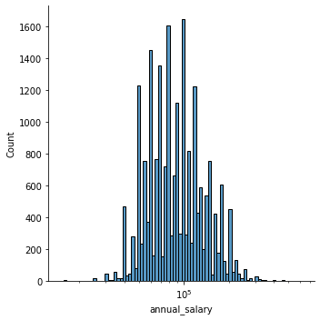

```python
sns.displot(df, x='annual_salary', log_scale=True)
```